# ANCOVA in Reading Comprehension (Reading Comprehension)

Geiser C. Challco geiser@alumni.usp.br

- Setting Initial Variables
- Descriptive Statistics of Initial Data
- ANCOVA and Pairwise for one factor: **grupo**
  - Without remove non-normal data
  - Computing ANCOVA and PairWise After removing non-normal data (OK)
    - Plots for ancova
    - Checking linearity assumption
    - Checking normality and homogeneity
- ANCOVA and Pairwise for two factors **grupo:Sexo**
  - Without remove non-normal data
  - Computing ANCOVA and PairWise After removing non-normal data (OK)
    - Plots for ancova
    - Checking linearity assumption
    - Checking normality and homogeneity
- ANCOVA and Pairwise for two factors **grupo:Zona**
  - Without remove non-normal data
  - Computing ANCOVA and PairWise After removing non-normal data (OK)
    - Plots for ancova
    - Checking linearity assumption
    - Checking normality and homogeneity
- ANCOVA and Pairwise for two factors **grupo:Cor.Raca**
  - Without remove non-normal data
  - Computing ANCOVA and PairWise After removing non-normal data (OK)
    - Plots for ancova
    - Checking linearity assumption
    - Checking normality and homogeneity
- ANCOVA and Pairwise for two factors **grupo:Serie**
  - Without remove non-normal data
  - Computing ANCOVA and PairWise After removing non-normal data (OK)
    - Plots for ancova
    - Checking linearity assumption
    - Checking normality and homogeneity
- ANCOVA and Pairwise for two factors **grupo:leitura.compreensao.quintile**
  - Without remove non-normal data
  - Computing ANCOVA and PairWise After removing non-normal data (OK)
    - Plots for ancova
    - Checking linearity assumption
    - Checking normality and homogeneity
- Summary of Results
  - Descriptive Statistics
  - ANCOVA Table Comparison
  - PairWise Table Comparison
  - EMMS Table Comparison

**NOTE**:

- Teste ANCOVA para determinar se houve diferenças significativas no Reading Comprehension (medido usando pre- e pos-testes).
- ANCOVA test to determine whether there were significant differences in Reading Comprehension (measured using pre- and post-tests).

# Setting Initial Variables

```r
dv = "leitura.compreensao"
dv.pos = "leitura.compreensao.pos"
dv.pre = "leitura.compreensao.pre"

fatores2 <- c("Sexo","Zona","Cor.Raca","Serie","leitura.compreensao.quintile")
lfatores2 <- as.list(fatores2)
names(lfatores2) <- fatores2

fatores1 <- c("grupo", fatores2)
lfatores1 <- as.list(fatores1)
names(lfatores1) <- fatores1

lfatores <- c(lfatores1)

color <- list()
color[["prepost"]] = c("#ffee65","#f28e2B")
color[["grupo"]] = c("#bcbd22","#fd7f6f")
color[["Sexo"]] = c("#FF007F","#4D4DFF")
color[["Zona"]] = c("#AA00FF","#00CCCC")
color[["Cor.Raca"]] = c(
  "Parda"="#b97100","Indígena"="#9F262F",
  "Branca"="#87c498", "Preta"="#848283","Amarela"="#D6B91C"
)

level <- list()
level[["grupo"]] = c("Controle","Experimental")
level[["Sexo"]] = c("F","M")
level[["Zona"]] = c("Rural","Urbana")
level[["Cor.Raca"]] = c("Parda","Indígena","Branca", "Preta","Amarela")
level[["Serie"]] = c("6 ano","7 ano","8 ano","9 ano")

# ..

ymin <- 0
ymax <- 0

ymin.ci <- 0
ymax.ci <- 0


color[["grupo:Sexo"]] = c(
  "Controle:F"="#ff99cb", "Controle:M"="#b7b7ff",
  "Experimental:F"="#FF007F", "Experimental:M"="#4D4DFF",
  "Controle.F"="#ff99cb", "Controle.M"="#b7b7ff",
  "Experimental.F"="#FF007F", "Experimental.M"="#4D4DFF"
)
color[["grupo:Zona"]] = c(
  "Controle:Rural"="#b2efef","Controle:Urbana"="#e5b2ff",
  "Experimental:Rural"="#00CCCC", "Experimental:Urbana"="#AA00FF",
  "Controle.Rural"="#b2efef","Controle.Urbana"="#e5b2ff",
  "Experimental.Rural"="#00CCCC", "Experimental.Urbana"="#AA00FF"
)
color[["grupo:Cor.Raca"]] = c(
    "Controle:Parda"="#e3c699", "Experimental:Parda"="#b97100",
    "Controle:Indígena"="#e2bdc0", "Experimental:Indígena"="#9F262F",
    "Controle:Branca"="#c0e8cb", "Experimental:Branca"="#87c498",
    "Controle:Preta"="#dad9d9", "Experimental:Preta"="#848283",
    "Controle:Amarela"="#eee3a4", "Experimental:Amarela"="#D6B91C",

    "Controle.Parda"="#e3c699", "Experimental.Parda"="#b97100",
    "Controle.Indígena"="#e2bdc0", "Experimental.Indígena"="#9F262F",
    "Controle.Branca"="#c0e8cb", "Experimental.Branca"="#87c498",
    "Controle.Preta"="#dad9d9", "Experimental.Preta"="#848283",
    "Controle.Amarela"="#eee3a4", "Experimental.Amarela"="#D6B91C"
)


for (coln in c("vocab","vocab.teach","vocab.non.teach","score.tde",
               "TFL.lidas.per.min","TFL.corretas.per.min","TFL.erradas.per.min","TFL.omitidas.per.min",
               "leitura.compreensao")) {
  color[[paste0(coln,".quintile")]] = c("#BF0040","#FF0000","#800080","#0000FF","#4000BF")
  level[[paste0(coln,".quintile")]] = c("1st quintile","2nd quintile","3rd quintile","4th quintile","5th quintile")
  color[[paste0("grupo:",coln,".quintile")]] = c(
    "Experimental.1st quintile"="#BF0040", "Controle.1st quintile"="#d8668c",
    "Experimental.2nd quintile"="#FF0000", "Controle.2nd quintile"="#ff7f7f",
    "Experimental.3rd quintile"="#8fce00", "Controle.3rd quintile"="#ddf0b2",
    "Experimental.4th quintile"="#0000FF", "Controle.4th quintile"="#b2b2ff",
    "Experimental.5th quintile"="#4000BF", "Controle.5th quintile"="#b299e5",

    "Experimental:1st quintile"="#BF0040", "Controle:1st quintile"="#d8668c",
    "Experimental:2nd quintile"="#FF0000", "Controle:2nd quintile"="#ff7f7f",
    "Experimental:3rd quintile"="#8fce00", "Controle:3rd quintile"="#ddf0b2",
    "Experimental:4th quintile"="#0000FF", "Controle:4th quintile"="#b2b2ff",
    "Experimental:5th quintile"="#4000BF", "Controle:5th quintile"="#b299e5")
}


gdat <- read_excel("../data/data.xlsx", sheet = "sumary")
gdat <- gdat[which(is.na(gdat$Necessidade.Deficiencia) & !is.na(gdat$Stari.Grupo)),]



dat <- gdat
dat$grupo <- factor(dat[["Stari.Grupo"]], level[["grupo"]])
for (coln in c(names(lfatores))) {
  dat[[coln]] <- factor(dat[[coln]], level[[coln]][level[[coln]] %in% unique(dat[[coln]])])
}
dat <- dat[which(!is.na(dat[[dv.pre]]) & !is.na(dat[[dv.pos]])),]
dat <- dat[,c("id",names(lfatores),dv.pre,dv.pos)]

dat.long <- rbind(dat, dat)
dat.long$time <- c(rep("pre", nrow(dat)), rep("pos", nrow(dat)))
dat.long$time <- factor(dat.long$time, c("pre","pos"))
dat.long[[dv]] <- c(dat[[dv.pre]], dat[[dv.pos]])


for (f in c("grupo", names(lfatores))) {
  if (is.null(color[[f]]) && length(unique(dat[[f]])) > 0)
      color[[f]] <- distinctColorPalette(length(unique(dat[[f]])))
}
for (f in c(fatores2)) {
  if (is.null(color[[paste0("grupo:",f)]]) && length(unique(dat[[f]])) > 0)
    color[[paste0("grupo:",f)]] <- distinctColorPalette(length(unique(dat[["grupo"]]))*length(unique(dat[[f]])))
}

ldat <- list()
laov <- list()
lpwc <- list()
lemms <- list()
```

# Descriptive Statistics of Initial Data

```r
df <- get.descriptives(dat, c(dv.pre, dv.pos), c("grupo"),
                       include.global = T, symmetry.test = T, normality.test = F)
df <- plyr::rbind.fill(
  df, do.call(plyr::rbind.fill, lapply(lfatores2, FUN = function(f) {
    if (nrow(dat) > 0 && sum(!is.na(unique(dat[[f]]))) > 1)
      get.descriptives(dat, c(dv.pre,dv.pos), c("grupo", f),
                       symmetry.test = T, normality.test = F)
    }))
)
df <- df[,c(fatores1[fatores1 %in% colnames(df)],"variable",
            colnames(df)[!colnames(df) %in% c(fatores1,"variable")])]
```

| grupo | Sexo | Zona | Cor.Raca | Serie | leitura.compreensao.quintile | variable | n | mean | median | min | max | sd | se | ci | iqr | symmetry | skewness | kurtosis |
| --- | --- | --- | --- | --- | --- | --- | --- | --- | --- | --- | --- | --- | --- | --- | --- | --- | --- | --- |
| Controle |  |  |  |  |  | leitura.compreensao.pre | 141 | 4.220 | 5.0 | 0 | 9 | 2.201 | 0.185 | 0.366 | 3.00 | YES | -0.378 | -0.522 |
| Experimental |  |  |  |  |  | leitura.compreensao.pre | 71 | 4.634 | 5.0 | 0 | 8 | 1.767 | 0.210 | 0.418 | 2.00 | YES | -0.425 | 0.191 |
|  |  |  |  |  |  | leitura.compreensao.pre | 212 | 4.358 | 5.0 | 0 | 9 | 2.071 | 0.142 | 0.280 | 3.00 | YES | -0.443 | -0.251 |
| Controle |  |  |  |  |  | leitura.compreensao.pos | 141 | 3.482 | 4.0 | 0 | 8 | 2.845 | 0.240 | 0.474 | 6.00 | YES | -0.092 | -1.528 |
| Experimental |  |  |  |  |  | leitura.compreensao.pos | 71 | 4.662 | 6.0 | 0 | 10 | 3.198 | 0.380 | 0.757 | 6.00 | YES | -0.371 | -1.327 |
|  |  |  |  |  |  | leitura.compreensao.pos | 212 | 3.877 | 5.0 | 0 | 10 | 3.012 | 0.207 | 0.408 | 6.00 | YES | -0.136 | -1.423 |
| Controle | F |  |  |  |  | leitura.compreensao.pre | 59 | 4.186 | 4.0 | 0 | 8 | 2.038 | 0.265 | 0.531 | 2.50 | YES | -0.357 | -0.311 |
| Controle | M |  |  |  |  | leitura.compreensao.pre | 82 | 4.244 | 5.0 | 0 | 9 | 2.323 | 0.257 | 0.510 | 3.00 | YES | -0.386 | -0.708 |
| Experimental | F |  |  |  |  | leitura.compreensao.pre | 29 | 4.828 | 5.0 | 3 | 8 | 1.284 | 0.238 | 0.488 | 2.00 | YES | 0.212 | -0.413 |
| Experimental | M |  |  |  |  | leitura.compreensao.pre | 42 | 4.500 | 5.0 | 0 | 8 | 2.039 | 0.315 | 0.635 | 2.00 | YES | -0.387 | -0.397 |
| Controle | F |  |  |  |  | leitura.compreensao.pos | 59 | 3.407 | 4.0 | 0 | 8 | 2.743 | 0.357 | 0.715 | 5.50 | YES | -0.135 | -1.500 |
| Controle | M |  |  |  |  | leitura.compreensao.pos | 82 | 3.537 | 4.0 | 0 | 8 | 2.932 | 0.324 | 0.644 | 6.00 | YES | -0.071 | -1.589 |
| Experimental | F |  |  |  |  | leitura.compreensao.pos | 29 | 4.655 | 5.0 | 0 | 9 | 3.165 | 0.588 | 1.204 | 6.00 | YES | -0.386 | -1.400 |
| Experimental | M |  |  |  |  | leitura.compreensao.pos | 42 | 4.667 | 6.0 | 0 | 10 | 3.259 | 0.503 | 1.015 | 6.50 | YES | -0.349 | -1.360 |
| Controle |  | Rural |  |  |  | leitura.compreensao.pre | 78 | 4.128 | 5.0 | 0 | 8 | 2.241 | 0.254 | 0.505 | 3.00 | YES | -0.493 | -0.812 |
| Controle |  | Urbana |  |  |  | leitura.compreensao.pre | 25 | 4.160 | 4.0 | 0 | 7 | 1.795 | 0.359 | 0.741 | 2.00 | NO | -0.644 | 0.071 |
| Controle |  |  |  |  |  | leitura.compreensao.pre | 38 | 4.447 | 4.0 | 0 | 9 | 2.390 | 0.388 | 0.786 | 2.50 | YES | -0.127 | -0.670 |
| Experimental |  | Rural |  |  |  | leitura.compreensao.pre | 42 | 4.714 | 5.0 | 0 | 8 | 1.979 | 0.305 | 0.617 | 2.00 | NO | -0.533 | 0.103 |
| Experimental |  | Urbana |  |  |  | leitura.compreensao.pre | 15 | 4.933 | 5.0 | 2 | 7 | 1.387 | 0.358 | 0.768 | 1.50 | NO | -0.640 | -0.704 |
| Experimental |  |  |  |  |  | leitura.compreensao.pre | 14 | 4.071 | 4.0 | 2 | 7 | 1.385 | 0.370 | 0.800 | 1.50 | YES | 0.367 | -0.507 |
| Controle |  | Rural |  |  |  | leitura.compreensao.pos | 78 | 4.038 | 5.0 | 0 | 8 | 2.728 | 0.309 | 0.615 | 4.00 | YES | -0.354 | -1.261 |
| Controle |  | Urbana |  |  |  | leitura.compreensao.pos | 25 | 1.200 | 0.0 | 0 | 7 | 2.327 | 0.465 | 0.961 | 1.00 | NO | 1.557 | 0.789 |
| Controle |  |  |  |  |  | leitura.compreensao.pos | 38 | 3.842 | 5.0 | 0 | 8 | 2.707 | 0.439 | 0.890 | 6.00 | YES | -0.403 | -1.303 |
| Experimental |  | Rural |  |  |  | leitura.compreensao.pos | 42 | 5.452 | 6.0 | 0 | 9 | 2.981 | 0.460 | 0.929 | 4.00 | NO | -0.787 | -0.773 |
| Experimental |  | Urbana |  |  |  | leitura.compreensao.pos | 15 | 2.133 | 0.0 | 0 | 7 | 2.825 | 0.729 | 1.564 | 5.00 | NO | 0.566 | -1.608 |
| Experimental |  |  |  |  |  | leitura.compreensao.pos | 14 | 5.000 | 5.0 | 0 | 10 | 2.987 | 0.798 | 1.725 | 3.75 | YES | -0.241 | -1.055 |
| Controle |  |  | Parda |  |  | leitura.compreensao.pre | 63 | 3.794 | 5.0 | 0 | 8 | 2.308 | 0.291 | 0.581 | 3.00 | YES | -0.418 | -1.024 |
| Controle |  |  | Indígena |  |  | leitura.compreensao.pre | 3 | 4.333 | 4.0 | 4 | 5 | 0.577 | 0.333 | 1.434 | 0.50 | few data | 0.000 | 0.000 |
| Controle |  |  | Branca |  |  | leitura.compreensao.pre | 14 | 4.714 | 6.0 | 0 | 8 | 2.785 | 0.744 | 1.608 | 4.00 | NO | -0.599 | -1.304 |
| Controle |  |  | Preta |  |  | leitura.compreensao.pre | 1 | 6.000 | 6.0 | 6 | 6 |  |  |  | 0.00 | few data | 0.000 | 0.000 |

[output cut: 52 more lines]

# ANCOVA and Pairwise for one factor: **grupo**

## Without remove non-normal data

```r
pdat = remove_group_data(dat[!is.na(dat[["grupo"]]),], "leitura.compreensao.pos", "grupo")

pdat.long <- rbind(pdat[,c("id","grupo")], pdat[,c("id","grupo")])
pdat.long[["time"]] <- c(rep("pre", nrow(pdat)), rep("pos", nrow(pdat)))
pdat.long[["time"]] <- factor(pdat.long[["time"]], c("pre","pos"))
pdat.long[["leitura.compreensao"]] <- c(pdat[["leitura.compreensao.pre"]], pdat[["leitura.compreensao.pos"]])

aov = anova_test(pdat, leitura.compreensao.pos ~ leitura.compreensao.pre + grupo)
laov[["grupo"]] <- get_anova_table(aov)
```

```r
pwc <- emmeans_test(pdat, leitura.compreensao.pos ~ grupo, covariate = leitura.compreensao.pre,
                    p.adjust.method = "bonferroni")
```

```r
pwc.long <- emmeans_test(dplyr::group_by_at(pdat.long, "grupo"),
                          leitura.compreensao ~ time,
                          p.adjust.method = "bonferroni")
lpwc[["grupo"]] <- plyr::rbind.fill(pwc, pwc.long)
```

```r
ds <- get.descriptives(pdat, "leitura.compreensao.pos", "grupo", covar = "leitura.compreensao.pre")
ds <- merge(ds[ds$variable != "leitura.compreensao.pre",],
            ds[ds$variable == "leitura.compreensao.pre", !colnames(ds) %in% c("variable")],
            by = "grupo", all.x = T, suffixes = c("", ".leitura.compreensao.pre"))
ds <- merge(get_emmeans(pwc), ds, by = "grupo", suffixes = c(".emms", ""))
ds <- ds[,c("grupo","n","mean.leitura.compreensao.pre","se.leitura.compreensao.pre","mean","se",
            "emmean","se.emms","conf.low","conf.high")]

colnames(ds) <- c("grupo", "N", paste0(c("M","SE")," (pre)"),
                  paste0(c("M","SE"), " (unadj)"),
                  paste0(c("M", "SE"), " (adj)"), "conf.low", "conf.high")

lemms[["grupo"]] <- ds
```

## Computing ANCOVA and PairWise After removing non-normal data (OK)

```r
wdat = pdat

res = residuals(lm(leitura.compreensao.pos ~ leitura.compreensao.pre + grupo, data = wdat))
non.normal = getNonNormal(res, wdat$id, plimit = 0.05)

wdat = wdat[!wdat$id %in% non.normal,]

wdat.long <- rbind(wdat[,c("id","grupo")], wdat[,c("id","grupo")])
wdat.long[["time"]] <- c(rep("pre", nrow(wdat)), rep("pos", nrow(wdat)))
wdat.long[["time"]] <- factor(wdat.long[["time"]], c("pre","pos"))
wdat.long[["leitura.compreensao"]] <- c(wdat[["leitura.compreensao.pre"]], wdat[["leitura.compreensao.pos"]])

ldat[["grupo"]] = wdat

(non.normal)
```

```
##  [1] "P2226" "P123"  "P140"  "P3049" "P1101" "P3035" "P3154" "P232"  "P3013" "P3165" "P3018"
## [12] "P2386" "P3014" "P246"  "P3170" "P3028" "P3234" "P3239" "P138"  "P3040" "P124"  "P3183"
## [23] "P3002" "P231"  "P3008" "P137"  "P3176" "P120"  "P126"  "P3178" "P3094" "P3016" "P3092"
## [34] "P3093" "P186"  "P1746" "P3091" "P3116" "P1098" "P1743" "P1716" "P813"  "P3181" "P941"
## [45] "P3153" "P3505" "P623"  "P612"  "P3032" "P182"  "P2383" "P3022" "P3027" "P3172" "P133"
## [56] "P614"  "P1742" "P3167" "P1089" "P3108" "P3055" "P3555" "P192"  "P1106" "P224"  "P2397"
## [67] "P459"  "P445"  "P3504" "P3160" "P625"  "P3174" "P3098" "P446"  "P3606" "P3518" "P3516"
## [78] "P176"  "P816"  "P3609" "P3598" "P3058" "P130"  "P228"
```

```r
aov = anova_test(wdat, leitura.compreensao.pos ~ leitura.compreensao.pre + grupo)
laov[["grupo"]] <- merge(get_anova_table(aov), laov[["grupo"]],
                            by="Effect", suffixes = c("","'"))

(df = get_anova_table(aov))
```

```
## ANOVA Table (type II tests)
##
##                    Effect DFn DFd      F        p p<.05   ges
## 1 leitura.compreensao.pre   1 125 53.010 3.25e-11     * 0.298
## 2                   grupo   1 125 30.645 1.74e-07     * 0.197
```

| Effect | DFn | DFd | F | p | p<.05 | ges |
| --- | --- | --- | --- | --- | --- | --- |
| leitura.compreensao.pre | 1 | 125 | 53.010 | 0 | * | 0.298 |
| grupo | 1 | 125 | 30.645 | 0 | * | 0.197 |

```r
pwc <- emmeans_test(wdat, leitura.compreensao.pos ~ grupo, covariate = leitura.compreensao.pre,
                    p.adjust.method = "bonferroni")
```

| term | .y. | group1 | group2 | df | statistic | p | p.adj | p.adj.signif |
| --- | --- | --- | --- | --- | --- | --- | --- | --- |
| leitura.compreensao.pre*grupo | leitura.compreensao.pos | Controle | Experimental | 125 | -5.536 | 0 | 0 | **** |

```r
pwc.long <- emmeans_test(dplyr::group_by_at(wdat.long, "grupo"),
                         leitura.compreensao ~ time,
                         p.adjust.method = "bonferroni")
lpwc[["grupo"]] <- merge(plyr::rbind.fill(pwc, pwc.long), lpwc[["grupo"]],
                            by=c("grupo","term",".y.","group1","group2"),
                            suffixes = c("","'"))
```

| grupo | term | .y. | group1 | group2 | df | statistic | p | p.adj | p.adj.signif |
| --- | --- | --- | --- | --- | --- | --- | --- | --- | --- |
| Controle | time | leitura.compreensao | pre | pos | 252 | -1.185 | 0.237 | 0.237 | ns |
| Experimental | time | leitura.compreensao | pre | pos | 252 | -4.220 | 0.000 | 0.000 | **** |

```r
ds <- get.descriptives(wdat, "leitura.compreensao.pos", "grupo", covar = "leitura.compreensao.pre")
ds <- merge(ds[ds$variable != "leitura.compreensao.pre",],
            ds[ds$variable == "leitura.compreensao.pre", !colnames(ds) %in% c("variable")],
            by = "grupo", all.x = T, suffixes = c("", ".leitura.compreensao.pre"))
ds <- merge(get_emmeans(pwc), ds, by = "grupo", suffixes = c(".emms", ""))
ds <- ds[,c("grupo","n","mean.leitura.compreensao.pre","se.leitura.compreensao.pre","mean","se",
            "emmean","se.emms","conf.low","conf.high")]

colnames(ds) <- c("grupo", "N", paste0(c("M","SE")," (pre)"),
                  paste0(c("M","SE"), " (unadj)"),
                  paste0(c("M", "SE"), " (adj)"), "conf.low", "conf.high")

lemms[["grupo"]] <- merge(ds, lemms[["grupo"]], by=c("grupo"), suffixes = c("","'"))
```

| grupo | N | M (pre) | SE (pre) | M (unadj) | SE (unadj) | M (adj) | SE (adj) | conf.low | conf.high |
| --- | --- | --- | --- | --- | --- | --- | --- | --- | --- |
| Controle | 85 | 4.400 | 0.249 | 4.753 | 0.201 | 4.784 | 0.160 | 4.468 | 5.100 |
| Experimental | 43 | 4.605 | 0.258 | 6.372 | 0.233 | 6.311 | 0.225 | 5.866 | 6.755 |

### Plots for ancova

```r
plots <- oneWayAncovaPlots(
  wdat, "leitura.compreensao.pos", "grupo", aov, list("grupo"=pwc), addParam = c("mean_ci"),
  font.label.size=10, step.increase=0.05, p.label="p.adj",
  subtitle = which(aov$Effect == "grupo"))
```

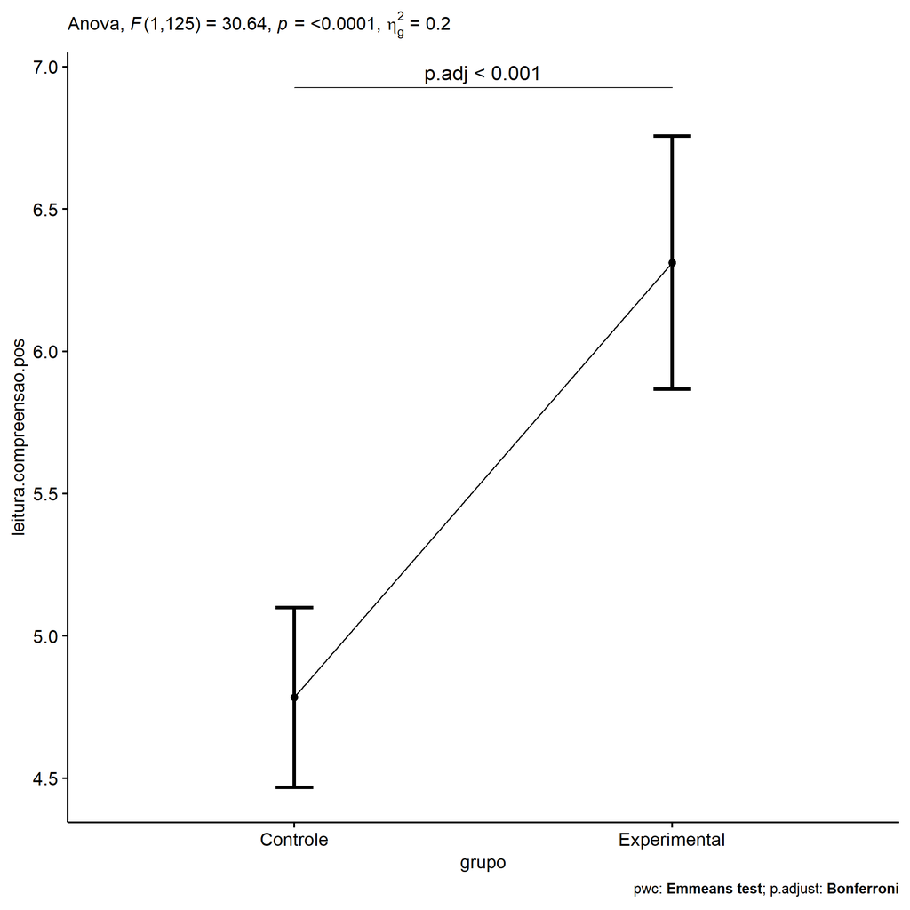

```r
if (!is.null(nrow(plots[["grupo"]]$data)))
  plots[["grupo"]] +
  if (ymin.ci < ymax.ci) ggplot2::ylim(ymin.ci, ymax.ci)
```

```r
plots <- oneWayAncovaBoxPlots(
  wdat, "leitura.compreensao.pos", "grupo", aov, pwc, covar = "leitura.compreensao.pre",
  theme = "classic", color = color[["grupo"]],
  subtitle = which(aov$Effect == "grupo"))
```

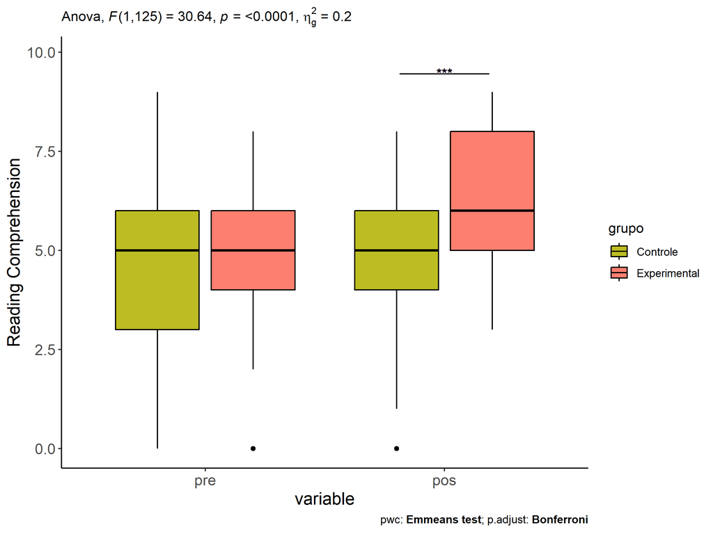

```r
if (length(unique(wdat[["grupo"]])) > 1)
  plots[["grupo"]] + ggplot2::ylab("Reading Comprehension") +
  ggplot2::scale_x_discrete(labels=c('pre', 'pos')) +
  if (ymin < ymax) ggplot2::ylim(ymin, ymax)
```

```r
if (length(unique(wdat.long[["grupo"]])) > 1)
  plots <- oneWayAncovaBoxPlots(
    wdat.long, "leitura.compreensao", "grupo", aov, pwc.long,
    pre.post = "time", theme = "classic", color = color$prepost)
```

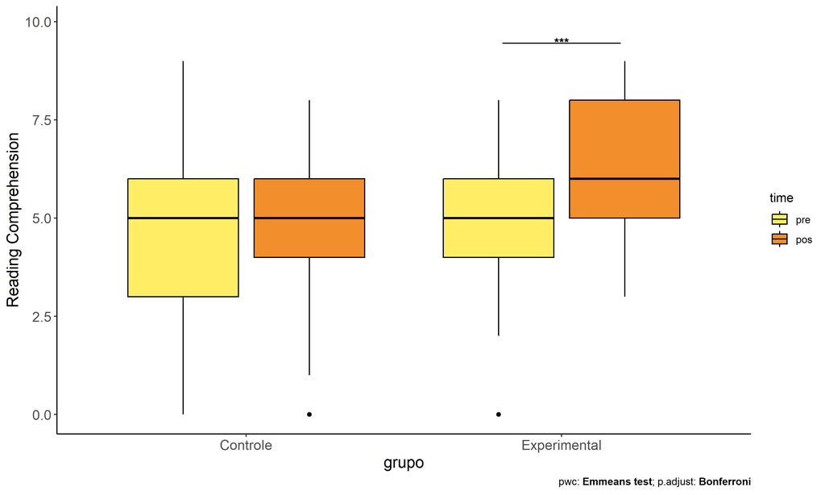

```r
if (length(unique(wdat.long[["grupo"]])) > 1)
  plots[["grupo"]] + ggplot2::ylab("Reading Comprehension") +
  if (ymin < ymax) ggplot2::ylim(ymin, ymax)
```

### Checking linearity assumption

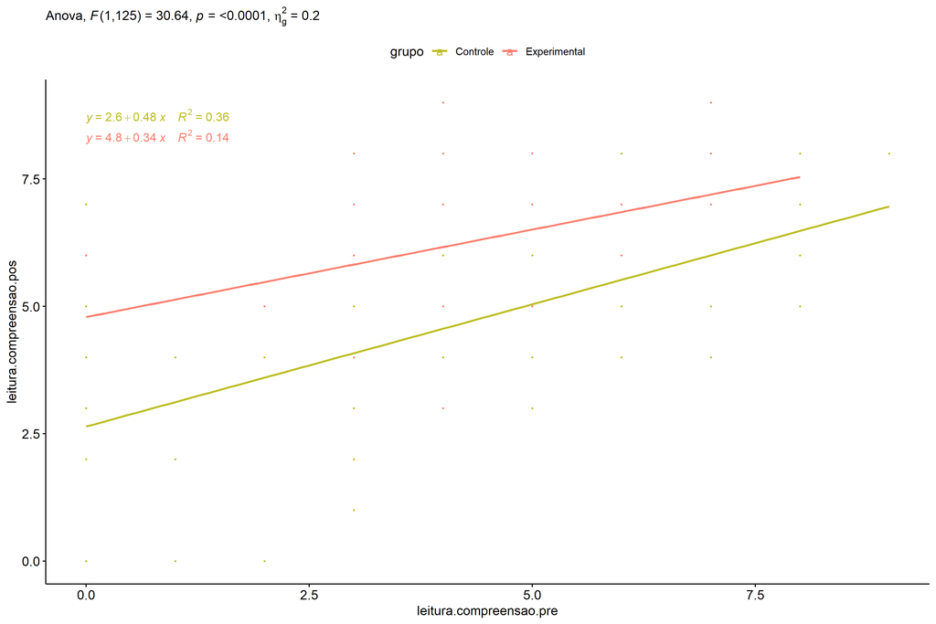

```r
ggscatter(wdat, x = "leitura.compreensao.pre", y = "leitura.compreensao.pos", size = 0.5,
          color = "grupo", add = "reg.line")+
  stat_regline_equation(
    aes(label =  paste(..eq.label.., ..rr.label.., sep = "~~~~"), color = grupo)
  ) +
  ggplot2::labs(subtitle = rstatix::get_test_label(aov, detailed = T, row = which(aov$Effect == "grupo"))) +
  ggplot2::scale_color_manual(values = color[["grupo"]]) +
  if (ymin < ymax) ggplot2::ylim(ymin, ymax)
```

### Checking normality and homogeneity

```r
res <- augment(lm(leitura.compreensao.pos ~ leitura.compreensao.pre + grupo, data = wdat))
```

```r
shapiro_test(res$.resid)
```

```
## # A tibble: 1 × 3
##   variable   statistic p.value
##   <chr>          <dbl>   <dbl>
## 1 res$.resid     0.983   0.104
```

```r
levene_test(res, .resid ~ grupo)
```

```
## # A tibble: 1 × 4
##     df1   df2 statistic     p
##   <int> <int>     <dbl> <dbl>
## 1     1   126   0.00771 0.930
```

# ANCOVA and Pairwise for two factors **grupo:Sexo**

## Without remove non-normal data

```r
pdat = remove_group_data(dat[!is.na(dat[["grupo"]]) & !is.na(dat[["Sexo"]]),],
                         "leitura.compreensao.pos", c("grupo","Sexo"))
pdat = pdat[pdat[["Sexo"]] %in% do.call(
  intersect, lapply(unique(pdat[["grupo"]]), FUN = function(x) {
    unique(pdat[["Sexo"]][which(pdat[["grupo"]] == x)])
  })),]
pdat[["grupo"]] = factor(pdat[["grupo"]], level[["grupo"]])
pdat[["Sexo"]] = factor(
  pdat[["Sexo"]],
  level[["Sexo"]][level[["Sexo"]] %in% unique(pdat[["Sexo"]])])

pdat.long <- rbind(pdat[,c("id","grupo","Sexo")], pdat[,c("id","grupo","Sexo")])
pdat.long[["time"]] <- c(rep("pre", nrow(pdat)), rep("pos", nrow(pdat)))
pdat.long[["time"]] <- factor(pdat.long[["time"]], c("pre","pos"))
pdat.long[["leitura.compreensao"]] <- c(pdat[["leitura.compreensao.pre"]], pdat[["leitura.compreensao.pos"]])

if (length(unique(pdat[["Sexo"]])) >= 2) {
  aov = anova_test(pdat, leitura.compreensao.pos ~ leitura.compreensao.pre + grupo*Sexo)
  laov[["grupo:Sexo"]] <- get_anova_table(aov)
}
```

```r
if (length(unique(pdat[["Sexo"]])) >= 2) {
  pwcs <- list()
  pwcs[["Sexo"]] <- emmeans_test(
    group_by(pdat, grupo), leitura.compreensao.pos ~ Sexo,
    covariate = leitura.compreensao.pre, p.adjust.method = "bonferroni")
  pwcs[["grupo"]] <- emmeans_test(
    group_by(pdat, Sexo), leitura.compreensao.pos ~ grupo,
    covariate = leitura.compreensao.pre, p.adjust.method = "bonferroni")

  pwc <- plyr::rbind.fill(pwcs[["grupo"]], pwcs[["Sexo"]])
  pwc <- pwc[,c("grupo","Sexo", colnames(pwc)[!colnames(pwc) %in% c("grupo","Sexo")])]
}
```

```r
if (length(unique(pdat[["Sexo"]])) >= 2) {
  pwc.long <- emmeans_test(dplyr::group_by_at(pdat.long, c("grupo","Sexo")),
                           leitura.compreensao ~ time,
                           p.adjust.method = "bonferroni")
  lpwc[["grupo:Sexo"]] <- plyr::rbind.fill(pwc, pwc.long)
}
```

```r
if (length(unique(pdat[["Sexo"]])) >= 2) {
  ds <- get.descriptives(pdat, "leitura.compreensao.pos", c("grupo","Sexo"), covar = "leitura.compreensao.pre")
  ds <- merge(ds[ds$variable != "leitura.compreensao.pre",],
              ds[ds$variable == "leitura.compreensao.pre", !colnames(ds) %in% c("variable")],
              by = c("grupo","Sexo"), all.x = T, suffixes = c("", ".leitura.compreensao.pre"))
  ds <- merge(get_emmeans(pwcs[["grupo"]]), ds,
              by = c("grupo","Sexo"), suffixes = c(".emms", ""))
  ds <- ds[,c("grupo","Sexo","n","mean.leitura.compreensao.pre","se.leitura.compreensao.pre","mean","se",
              "emmean","se.emms","conf.low","conf.high")]

  colnames(ds) <- c("grupo","Sexo", "N", paste0(c("M","SE")," (pre)"),
                    paste0(c("M","SE"), " (unadj)"),
                    paste0(c("M", "SE"), " (adj)"), "conf.low", "conf.high")

  lemms[["grupo:Sexo"]] <- ds
}
```

## Computing ANCOVA and PairWise After removing non-normal data (OK)

```r
if (length(unique(pdat[["Sexo"]])) >= 2) {
  wdat = pdat

  res = residuals(lm(leitura.compreensao.pos ~ leitura.compreensao.pre + grupo*Sexo, data = wdat))
  non.normal = getNonNormal(res, wdat$id, plimit = 0.05)

  wdat = wdat[!wdat$id %in% non.normal,]

  wdat.long <- rbind(wdat[,c("id","grupo","Sexo")], wdat[,c("id","grupo","Sexo")])
  wdat.long[["time"]] <- c(rep("pre", nrow(wdat)), rep("pos", nrow(wdat)))
  wdat.long[["time"]] <- factor(wdat.long[["time"]], c("pre","pos"))
  wdat.long[["leitura.compreensao"]] <- c(wdat[["leitura.compreensao.pre"]], wdat[["leitura.compreensao.pos"]])


  ldat[["grupo:Sexo"]] = wdat

  (non.normal)
}
```

```
##   [1] "P123"  "P140"  "P2226" "P3049" "P1101" "P3035" "P3165" "P3154" "P232"  "P3013" "P3018"
##  [12] "P2386" "P3170" "P3014" "P246"  "P3028" "P3234" "P3239" "P138"  "P3040" "P124"  "P3183"
##  [23] "P231"  "P3008" "P120"  "P126"  "P3016" "P3002" "P137"  "P3176" "P3178" "P3094" "P3092"
##  [34] "P3093" "P186"  "P3091" "P1098" "P2397" "P192"  "P1743" "P1746" "P3116" "P813"  "P228"
##  [45] "P3153" "P613"  "P3505" "P941"  "P623"  "P615"  "P3032" "P3181" "P3022" "P182"  "P2383"
##  [56] "P3172" "P3027" "P3058" "P612"  "P1716" "P3108" "P133"  "P510"  "P1742" "P1089" "P1106"
##  [67] "P459"  "P614"  "P3509" "P445"  "P625"  "P958"  "P953"  "P1022" "P521"  "P446"  "P1016"
##  [78] "P952"  "P3518" "P816"  "P3609" "P448"  "P3598" "P626"  "P515"  "P622"  "P512"  "P523"
##  [89] "P936"  "P3627" "P3577" "P3729" "P2404" "P176"  "P621"  "P3521" "P3508" "P945"  "P2385"
## [100] "P812"  "P950"  "P956"  "P2250" "P628"  "P3498" "P121"  "P2294" "P1107" "P3524" "P3512"
## [111] "P522"  "P1109" "P997"  "P2209" "P451"  "P2376" "P241"  "P449"  "P1764" "P1762" "P1699"
## [122] "P1017" "P3566" "P829"  "P174"  "P3558" "P948"  "P3615" "P3630" "P3565" "P620"  "P2249"
## [133] "P3581" "P960"  "P1091" "P2239" "P3519" "P1097" "P184"  "P3560" "P947"  "P3502" "P2210"
## [144] "P3495" "P1000" "P2222" "P808"  "P516"  "P2211" "P3501" "P3624" "P1004" "P3511" "P3734"
## [155] "P463"  "P3492" "P458"  "P464"  "P2378" "P943"  "P618"  "P2402" "P2408" "P2214" "P1728"
## [166] "P942"  "P2247" "P143"  "P2377" "P616"  "P1698" "P128"  "P457"  "P2390" "P1094" "P513"
## [177] "P1084" "P2293" "P3578" "P2244" "P1768"
```

```r
if (length(unique(pdat[["Sexo"]])) >= 2) {
  aov = anova_test(wdat, leitura.compreensao.pos ~ leitura.compreensao.pre + grupo*Sexo)
  laov[["grupo:Sexo"]] <- merge(get_anova_table(aov), laov[["grupo:Sexo"]],
                                         by="Effect", suffixes = c("","'"))
  df = get_anova_table(aov)
}
```

| Effect | DFn | DFd | F | p | p<.05 | ges |
| --- | --- | --- | --- | --- | --- | --- |
| leitura.compreensao.pre | 1 | 26 | 74.012 | 0.000 | * | 0.740 |
| grupo | 1 | 26 | 2.904 | 0.100 |  | 0.100 |
| Sexo | 1 | 26 | 0.104 | 0.750 |  | 0.004 |
| grupo:Sexo | 1 | 26 | 4.510 | 0.043 | * | 0.148 |

```r
if (length(unique(pdat[["Sexo"]])) >= 2) {
  pwcs <- list()
  pwcs[["Sexo"]] <- emmeans_test(
    group_by(wdat, grupo), leitura.compreensao.pos ~ Sexo,
    covariate = leitura.compreensao.pre, p.adjust.method = "bonferroni")
  pwcs[["grupo"]] <- emmeans_test(
    group_by(wdat, Sexo), leitura.compreensao.pos ~ grupo,
    covariate = leitura.compreensao.pre, p.adjust.method = "bonferroni")

  pwc <- plyr::rbind.fill(pwcs[["grupo"]], pwcs[["Sexo"]])
  pwc <- pwc[,c("grupo","Sexo", colnames(pwc)[!colnames(pwc) %in% c("grupo","Sexo")])]
}
```

| grupo | Sexo | term | .y. | group1 | group2 | df | statistic | p | p.adj | p.adj.signif |
| --- | --- | --- | --- | --- | --- | --- | --- | --- | --- | --- |
|  | F | leitura.compreensao.pre*grupo | leitura.compreensao.pos | Controle | Experimental | 26 | -2.712 | 0.012 | 0.012 | * |
|  | M | leitura.compreensao.pre*grupo | leitura.compreensao.pos | Controle | Experimental | 26 | -0.309 | 0.759 | 0.759 | ns |
| Controle |  | leitura.compreensao.pre*Sexo | leitura.compreensao.pos | F | M | 26 | -1.249 | 0.223 | 0.223 | ns |
| Experimental |  | leitura.compreensao.pre*Sexo | leitura.compreensao.pos | F | M | 26 | 1.729 | 0.096 | 0.096 | ns |

```r
if (length(unique(pdat[["Sexo"]])) >= 2) {
  pwc.long <- emmeans_test(dplyr::group_by_at(wdat.long, c("grupo","Sexo")),
                           leitura.compreensao ~ time,
                           p.adjust.method = "bonferroni")
  lpwc[["grupo:Sexo"]] <- merge(plyr::rbind.fill(pwc, pwc.long),
                                         lpwc[["grupo:Sexo"]],
                                         by=c("grupo","Sexo","term",".y.","group1","group2"),
                                         suffixes = c("","'"))
}
```

| grupo | Sexo | term | .y. | group1 | group2 | df | statistic | p | p.adj | p.adj.signif |
| --- | --- | --- | --- | --- | --- | --- | --- | --- | --- | --- |
| Controle | F | time | leitura.compreensao | pre | pos | 54 | 1.853 | 0.069 | 0.069 | ns |
| Controle | M | time | leitura.compreensao | pre | pos | 54 | 1.485 | 0.143 | 0.143 | ns |
| Experimental | F | time | leitura.compreensao | pre | pos | 54 | 0.247 | 0.806 | 0.806 | ns |
| Experimental | M | time | leitura.compreensao | pre | pos | 54 | 1.094 | 0.279 | 0.279 | ns |

```r
if (length(unique(pdat[["Sexo"]])) >= 2) {
  ds <- get.descriptives(wdat, "leitura.compreensao.pos", c("grupo","Sexo"), covar = "leitura.compreensao.pre")
  ds <- merge(ds[ds$variable != "leitura.compreensao.pre",],
              ds[ds$variable == "leitura.compreensao.pre", !colnames(ds) %in% c("variable")],
              by = c("grupo","Sexo"), all.x = T, suffixes = c("", ".leitura.compreensao.pre"))
  ds <- merge(get_emmeans(pwcs[["grupo"]]), ds,
              by = c("grupo","Sexo"), suffixes = c(".emms", ""))
  ds <- ds[,c("grupo","Sexo","n","mean.leitura.compreensao.pre","se.leitura.compreensao.pre",
              "mean","se","emmean","se.emms","conf.low","conf.high")]

  colnames(ds) <- c("grupo","Sexo", "N", paste0(c("M","SE")," (pre)"),
                    paste0(c("M","SE"), " (unadj)"),
                    paste0(c("M", "SE"), " (adj)"), "conf.low", "conf.high")

  lemms[["grupo:Sexo"]] <- merge(ds, lemms[["grupo:Sexo"]],
                                          by=c("grupo","Sexo"), suffixes = c("","'"))
}
```

| grupo | Sexo | N | M (pre) | SE (pre) | M (unadj) | SE (unadj) | M (adj) | SE (adj) | conf.low | conf.high |
| --- | --- | --- | --- | --- | --- | --- | --- | --- | --- | --- |
| Controle | F | 8 | 3.250 | 0.750 | 1.375 | 0.596 | 1.183 | 0.305 | 0.556 | 1.810 |
| Controle | M | 16 | 2.375 | 0.569 | 1.312 | 0.384 | 1.655 | 0.219 | 1.205 | 2.105 |
| Experimental | F | 2 | 4.500 | 1.500 | 4.000 | 1.000 | 3.044 | 0.619 | 1.772 | 4.316 |
| Experimental | M | 5 | 3.600 | 1.288 | 2.200 | 0.917 | 1.794 | 0.388 | 0.997 | 2.591 |

### Plots for ancova

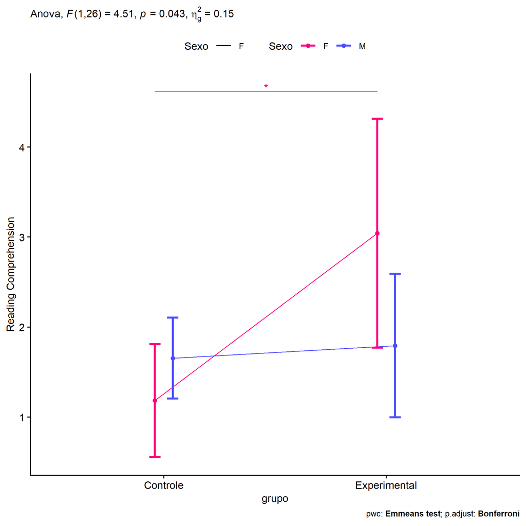

```r
if (length(unique(pdat[["Sexo"]])) >= 2) {
  ggPlotAoC2(pwcs, "grupo", "Sexo", aov, ylab = "Reading Comprehension",
             subtitle = which(aov$Effect == "grupo:Sexo"), addParam = "errorbar") +
    ggplot2::scale_color_manual(values = color[["Sexo"]]) +
    if (ymin.ci < ymax.ci) ggplot2::ylim(ymin.ci, ymax.ci)
}
```

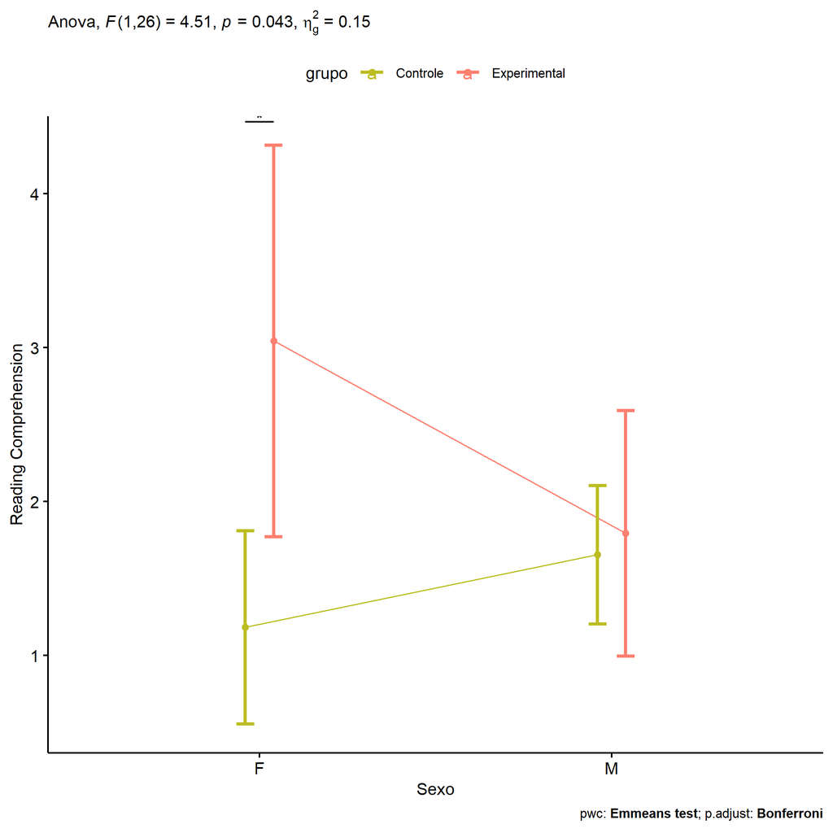

```r
if (length(unique(pdat[["Sexo"]])) >= 2) {
  ggPlotAoC2(pwcs, "Sexo", "grupo", aov, ylab = "Reading Comprehension",
               subtitle = which(aov$Effect == "grupo:Sexo"), addParam = "errorbar") +
      ggplot2::scale_color_manual(values = color[["grupo"]]) +
      if (ymin.ci < ymax.ci) ggplot2::ylim(ymin.ci, ymax.ci)
}
```

```r
if (length(unique(pdat[["Sexo"]])) >= 2) {
  plots <- twoWayAncovaBoxPlots(
    wdat, "leitura.compreensao.pos", c("grupo","Sexo"), aov, pwcs, covar = "leitura.compreensao.pre",
    theme = "classic", color = color[["grupo:Sexo"]],
    subtitle = which(aov$Effect == "grupo:Sexo"))
}
```

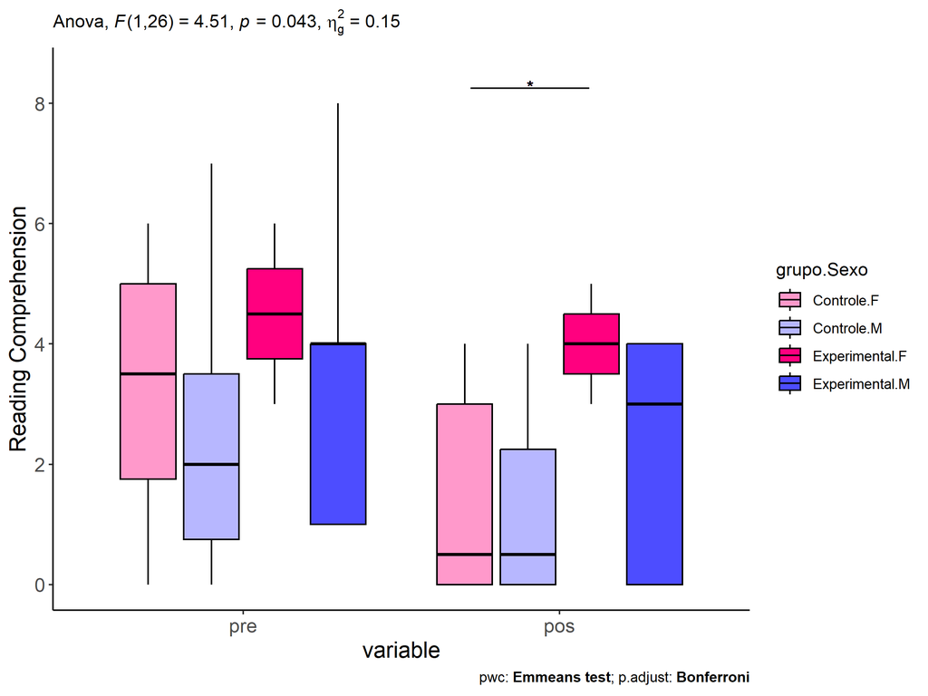

```r
if (length(unique(pdat[["Sexo"]])) >= 2) {
  plots[["grupo:Sexo"]] + ggplot2::ylab("Reading Comprehension") +
  ggplot2::scale_x_discrete(labels=c('pre', 'pos')) +
  if (ymin < ymax) ggplot2::ylim(ymin, ymax)
}
```

```r
if (length(unique(pdat[["Sexo"]])) >= 2) {
  plots <- twoWayAncovaBoxPlots(
    wdat.long, "leitura.compreensao", c("grupo","Sexo"), aov, pwc.long,
    pre.post = "time",
    theme = "classic", color = color$prepost)
}
```

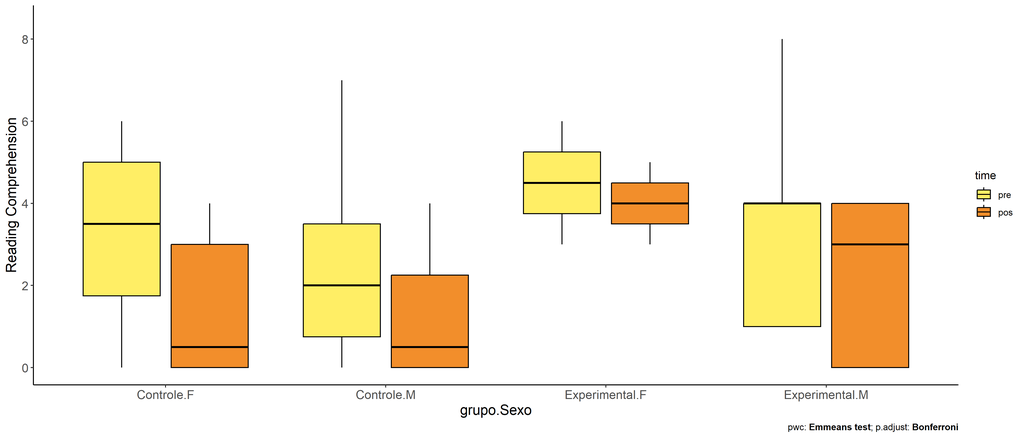

```r
if (length(unique(pdat[["Sexo"]])) >= 2)
  plots[["grupo:Sexo"]] + ggplot2::ylab("Reading Comprehension") +
    if (ymin < ymax) ggplot2::ylim(ymin, ymax)
```

### Checking linearity assumption

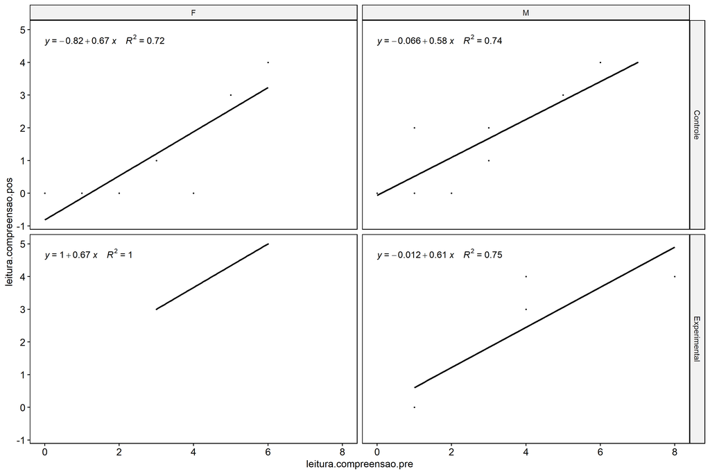

```r
if (length(unique(pdat[["Sexo"]])) >= 2) {
  ggscatter(wdat, x = "leitura.compreensao.pre", y = "leitura.compreensao.pos", size = 0.5,
            facet.by = c("grupo","Sexo"), add = "reg.line")+
    stat_regline_equation(
      aes(label =  paste(..eq.label.., ..rr.label.., sep = "~~~~"))
    ) +
    if (ymin < ymax) ggplot2::ylim(ymin, ymax)
}
```

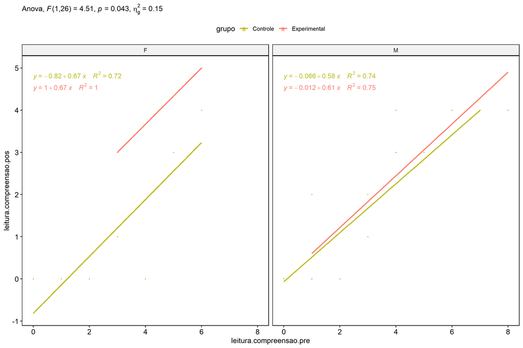

```r
if (length(unique(pdat[["Sexo"]])) >= 2) {
  ggscatter(wdat, x = "leitura.compreensao.pre", y = "leitura.compreensao.pos", size = 0.5,
            color = "grupo", facet.by = "Sexo", add = "reg.line")+
    stat_regline_equation(
      aes(label =  paste(..eq.label.., ..rr.label.., sep = "~~~~"), color = grupo)
    ) +
    ggplot2::labs(subtitle = rstatix::get_test_label(aov, detailed = T, row = which(aov$Effect == "grupo:Sexo"))) +
    ggplot2::scale_color_manual(values = color[["grupo"]]) +
    if (ymin < ymax) ggplot2::ylim(ymin, ymax)
}
```

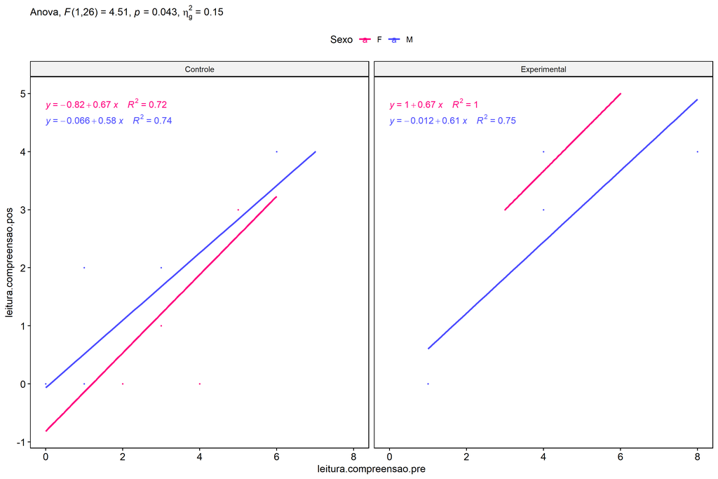

```r
if (length(unique(pdat[["Sexo"]])) >= 2) {
  ggscatter(wdat, x = "leitura.compreensao.pre", y = "leitura.compreensao.pos", size = 0.5,
            color = "Sexo", facet.by = "grupo", add = "reg.line")+
    stat_regline_equation(
      aes(label =  paste(..eq.label.., ..rr.label.., sep = "~~~~"), color = Sexo)
    ) +
    ggplot2::labs(subtitle = rstatix::get_test_label(aov, detailed = T, row = which(aov$Effect == "grupo:Sexo"))) +
    ggplot2::scale_color_manual(values = color[["Sexo"]]) +
    if (ymin < ymax) ggplot2::ylim(ymin, ymax)
}
```

### Checking normality and homogeneity

```r
if (length(unique(pdat[["Sexo"]])) >= 2)
  res <- augment(lm(leitura.compreensao.pos ~ leitura.compreensao.pre + grupo*Sexo, data = wdat))
```

```r
if (length(unique(pdat[["Sexo"]])) >= 2)
  shapiro_test(res$.resid)
```

```
## # A tibble: 1 × 3
##   variable   statistic p.value
##   <chr>          <dbl>   <dbl>
## 1 res$.resid     0.968   0.453
```

```r
if (length(unique(pdat[["Sexo"]])) >= 2)
  levene_test(res, .resid ~ grupo*Sexo)
```

```
## # A tibble: 1 × 4
##     df1   df2 statistic     p
##   <int> <int>     <dbl> <dbl>
## 1     3    27     0.550 0.652
```

# ANCOVA and Pairwise for two factors **grupo:Zona**

## Without remove non-normal data

```r
pdat = remove_group_data(dat[!is.na(dat[["grupo"]]) & !is.na(dat[["Zona"]]),],
                         "leitura.compreensao.pos", c("grupo","Zona"))
pdat = pdat[pdat[["Zona"]] %in% do.call(
  intersect, lapply(unique(pdat[["grupo"]]), FUN = function(x) {
    unique(pdat[["Zona"]][which(pdat[["grupo"]] == x)])
  })),]
pdat[["grupo"]] = factor(pdat[["grupo"]], level[["grupo"]])
pdat[["Zona"]] = factor(
  pdat[["Zona"]],
  level[["Zona"]][level[["Zona"]] %in% unique(pdat[["Zona"]])])

pdat.long <- rbind(pdat[,c("id","grupo","Zona")], pdat[,c("id","grupo","Zona")])
pdat.long[["time"]] <- c(rep("pre", nrow(pdat)), rep("pos", nrow(pdat)))
pdat.long[["time"]] <- factor(pdat.long[["time"]], c("pre","pos"))
pdat.long[["leitura.compreensao"]] <- c(pdat[["leitura.compreensao.pre"]], pdat[["leitura.compreensao.pos"]])

if (length(unique(pdat[["Zona"]])) >= 2) {
  aov = anova_test(pdat, leitura.compreensao.pos ~ leitura.compreensao.pre + grupo*Zona)
  laov[["grupo:Zona"]] <- get_anova_table(aov)
}
```

```r
if (length(unique(pdat[["Zona"]])) >= 2) {
  pwcs <- list()
  pwcs[["Zona"]] <- emmeans_test(
    group_by(pdat, grupo), leitura.compreensao.pos ~ Zona,
    covariate = leitura.compreensao.pre, p.adjust.method = "bonferroni")
  pwcs[["grupo"]] <- emmeans_test(
    group_by(pdat, Zona), leitura.compreensao.pos ~ grupo,
    covariate = leitura.compreensao.pre, p.adjust.method = "bonferroni")

  pwc <- plyr::rbind.fill(pwcs[["grupo"]], pwcs[["Zona"]])
  pwc <- pwc[,c("grupo","Zona", colnames(pwc)[!colnames(pwc) %in% c("grupo","Zona")])]
}
```

```r
if (length(unique(pdat[["Zona"]])) >= 2) {
  pwc.long <- emmeans_test(dplyr::group_by_at(pdat.long, c("grupo","Zona")),
                           leitura.compreensao ~ time,
                           p.adjust.method = "bonferroni")
  lpwc[["grupo:Zona"]] <- plyr::rbind.fill(pwc, pwc.long)
}
```

```r
if (length(unique(pdat[["Zona"]])) >= 2) {
  ds <- get.descriptives(pdat, "leitura.compreensao.pos", c("grupo","Zona"), covar = "leitura.compreensao.pre")
  ds <- merge(ds[ds$variable != "leitura.compreensao.pre",],
              ds[ds$variable == "leitura.compreensao.pre", !colnames(ds) %in% c("variable")],
              by = c("grupo","Zona"), all.x = T, suffixes = c("", ".leitura.compreensao.pre"))
  ds <- merge(get_emmeans(pwcs[["grupo"]]), ds,
              by = c("grupo","Zona"), suffixes = c(".emms", ""))
  ds <- ds[,c("grupo","Zona","n","mean.leitura.compreensao.pre","se.leitura.compreensao.pre","mean","se",
              "emmean","se.emms","conf.low","conf.high")]

  colnames(ds) <- c("grupo","Zona", "N", paste0(c("M","SE")," (pre)"),
                    paste0(c("M","SE"), " (unadj)"),
                    paste0(c("M", "SE"), " (adj)"), "conf.low", "conf.high")

  lemms[["grupo:Zona"]] <- ds
}
```

```r
if (length(unique(pdat[["Zona"]])) >= 2) {
  wdat = pdat

  res = residuals(lm(leitura.compreensao.pos ~ leitura.compreensao.pre + grupo*Zona, data = wdat))
  non.normal = getNonNormal(res, wdat$id, plimit = 0.05)

  wdat = wdat[!wdat$id %in% non.normal,]

  wdat.long <- rbind(wdat[,c("id","grupo","Zona")], wdat[,c("id","grupo","Zona")])
  wdat.long[["time"]] <- c(rep("pre", nrow(wdat)), rep("pos", nrow(wdat)))
  wdat.long[["time"]] <- factor(wdat.long[["time"]], c("pre","pos"))
  wdat.long[["leitura.compreensao"]] <- c(wdat[["leitura.compreensao.pre"]], wdat[["leitura.compreensao.pos"]])


  ldat[["grupo:Zona"]] = wdat

  (non.normal)
}
```

```
##  [1] "P2404" "P1101" "P121"  "P241"  "P623"  "P2250" "P613"  "P960"  "P941"  "P1762" "P2211"
## [12] "P3013" "P3505" "P612"  "P615"  "P510"  "P143"  "P614"  "P3018" "P1728" "P128"  "P459"
## [23] "P3509" "P445"  "P3170" "P625"  "P952"  "P448"  "P958"  "P446"  "P3518" "P3028" "P816"
## [34] "P3609" "P622"  "P512"  "P1713" "P3040" "P3598" "P626"  "P953"  "P3183" "P515"  "P3002"
## [45] "P521"  "P936"  "P523"  "P3008" "P3729" "P621"  "P3094" "P3521" "P3508" "P945"  "P3016"
## [56] "P3577" "P812"  "P950"  "P3092" "P628"  "P1746" "P956"  "P238"  "P522"  "P3174" "P3498"
## [67] "P997"  "P1742" "P3512" "P451"  "P1764" "P1699" "P3555" "P449"  "P829"  "P948"  "P3615"
## [78] "P3630" "P3565" "P3167" "P174"  "P3581" "P1716" "P620"  "P3519" "P3495" "P1743" "P947"
## [89] "P3502" "P3172" "P2210" "P3501" "P516"  "P3027" "P3108" "P130"  "P3624" "P1004"
```

```r
if (length(unique(pdat[["Zona"]])) >= 2) {
  aov = anova_test(wdat, leitura.compreensao.pos ~ leitura.compreensao.pre + grupo*Zona)
  laov[["grupo:Zona"]] <- merge(get_anova_table(aov), laov[["grupo:Zona"]],
                                         by="Effect", suffixes = c("","'"))
  df = get_anova_table(aov)
}
```

| Effect | DFn | DFd | F | p | p<.05 | ges |
| --- | --- | --- | --- | --- | --- | --- |
| leitura.compreensao.pre | 1 | 57 | 41.047 | 0.000 | * | 0.419 |
| grupo | 1 | 57 | 2.138 | 0.149 |  | 0.036 |
| Zona | 1 | 57 | 154.052 | 0.000 | * | 0.730 |
| grupo:Zona | 1 | 57 | 8.929 | 0.004 | * | 0.135 |

```r
if (length(unique(pdat[["Zona"]])) >= 2) {
  pwcs <- list()
  pwcs[["Zona"]] <- emmeans_test(
    group_by(wdat, grupo), leitura.compreensao.pos ~ Zona,
    covariate = leitura.compreensao.pre, p.adjust.method = "bonferroni")
  pwcs[["grupo"]] <- emmeans_test(
    group_by(wdat, Zona), leitura.compreensao.pos ~ grupo,
    covariate = leitura.compreensao.pre, p.adjust.method = "bonferroni")

  pwc <- plyr::rbind.fill(pwcs[["grupo"]], pwcs[["Zona"]])
  pwc <- pwc[,c("grupo","Zona", colnames(pwc)[!colnames(pwc) %in% c("grupo","Zona")])]
}
```

| grupo | Zona | term | .y. | group1 | group2 | df | statistic | p | p.adj | p.adj.signif |
| --- | --- | --- | --- | --- | --- | --- | --- | --- | --- | --- |
|  | Rural | leitura.compreensao.pre*grupo | leitura.compreensao.pos | Controle | Experimental | 57 | -3.166 | 0.002 | 0.002 | ** |
|  | Urbana | leitura.compreensao.pre*grupo | leitura.compreensao.pos | Controle | Experimental | 57 | 0.934 | 0.354 | 0.354 | ns |
| Controle |  | leitura.compreensao.pre*Zona | leitura.compreensao.pos | Rural | Urbana | 57 | 9.013 | 0.000 | 0.000 | **** |
| Experimental |  | leitura.compreensao.pre*Zona | leitura.compreensao.pos | Rural | Urbana | 57 | 9.007 | 0.000 | 0.000 | **** |

```r
if (length(unique(pdat[["Zona"]])) >= 2) {
  pwc.long <- emmeans_test(dplyr::group_by_at(wdat.long, c("grupo","Zona")),
                           leitura.compreensao ~ time,
                           p.adjust.method = "bonferroni")
  lpwc[["grupo:Zona"]] <- merge(plyr::rbind.fill(pwc, pwc.long),
                                         lpwc[["grupo:Zona"]],
                                         by=c("grupo","Zona","term",".y.","group1","group2"),
                                         suffixes = c("","'"))
}
```

| grupo | Zona | term | .y. | group1 | group2 | df | statistic | p | p.adj | p.adj.signif |
| --- | --- | --- | --- | --- | --- | --- | --- | --- | --- | --- |
| Controle | Rural | time | leitura.compreensao | pre | pos | 116 | 2.136 | 0.035 | 0.035 | * |
| Controle | Urbana | time | leitura.compreensao | pre | pos | 116 | 7.888 | 0.000 | 0.000 | **** |
| Experimental | Rural | time | leitura.compreensao | pre | pos | 116 | 0.329 | 0.743 | 0.743 | ns |
| Experimental | Urbana | time | leitura.compreensao | pre | pos | 116 | 6.519 | 0.000 | 0.000 | **** |

```r
if (length(unique(pdat[["Zona"]])) >= 2) {
  ds <- get.descriptives(wdat, "leitura.compreensao.pos", c("grupo","Zona"), covar = "leitura.compreensao.pre")
  ds <- merge(ds[ds$variable != "leitura.compreensao.pre",],
              ds[ds$variable == "leitura.compreensao.pre", !colnames(ds) %in% c("variable")],
              by = c("grupo","Zona"), all.x = T, suffixes = c("", ".leitura.compreensao.pre"))
  ds <- merge(get_emmeans(pwcs[["grupo"]]), ds,
              by = c("grupo","Zona"), suffixes = c(".emms", ""))
  ds <- ds[,c("grupo","Zona","n","mean.leitura.compreensao.pre","se.leitura.compreensao.pre",
              "mean","se","emmean","se.emms","conf.low","conf.high")]

  colnames(ds) <- c("grupo","Zona", "N", paste0(c("M","SE")," (pre)"),
                    paste0(c("M","SE"), " (unadj)"),
                    paste0(c("M", "SE"), " (adj)"), "conf.low", "conf.high")

  lemms[["grupo:Zona"]] <- merge(ds, lemms[["grupo:Zona"]],
                                          by=c("grupo","Zona"), suffixes = c("","'"))
}
```

| grupo | Zona | N | M (pre) | SE (pre) | M (unadj) | SE (unadj) | M (adj) | SE (adj) | conf.low | conf.high |
| --- | --- | --- | --- | --- | --- | --- | --- | --- | --- | --- |
| Controle | Rural | 28 | 3.571 | 0.432 | 2.643 | 0.368 | 2.942 | 0.205 | 2.532 | 3.352 |
| Controle | Urbana | 18 | 4.389 | 0.304 | 0.111 | 0.076 | 0.017 | 0.249 | -0.481 | 0.516 |
| Experimental | Rural | 7 | 5.143 | 0.595 | 4.857 | 0.340 | 4.401 | 0.405 | 3.590 | 5.212 |
| Experimental | Urbana | 9 | 5.000 | 0.441 | 0.000 | 0.000 | -0.387 | 0.357 | -1.102 | 0.327 |

### Plots for ancova

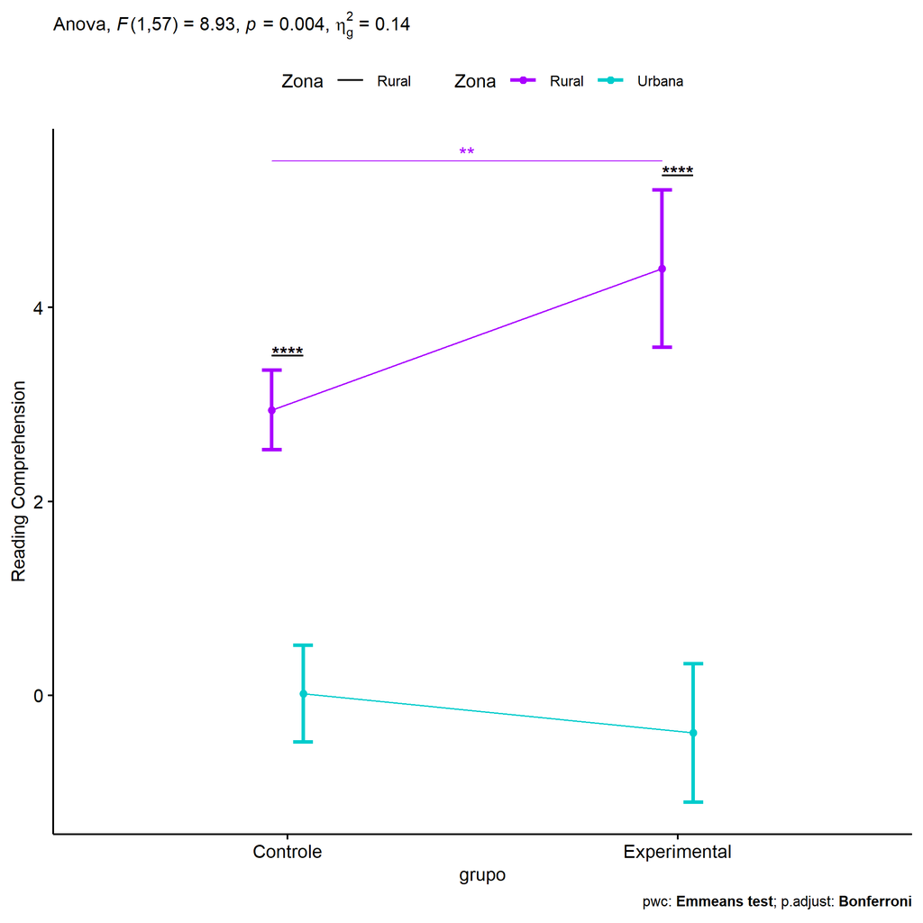

```r
if (length(unique(pdat[["Zona"]])) >= 2) {
  ggPlotAoC2(pwcs, "grupo", "Zona", aov, ylab = "Reading Comprehension",
             subtitle = which(aov$Effect == "grupo:Zona"), addParam = "errorbar") +
    ggplot2::scale_color_manual(values = color[["Zona"]]) +
    if (ymin.ci < ymax.ci) ggplot2::ylim(ymin.ci, ymax.ci)
}
```

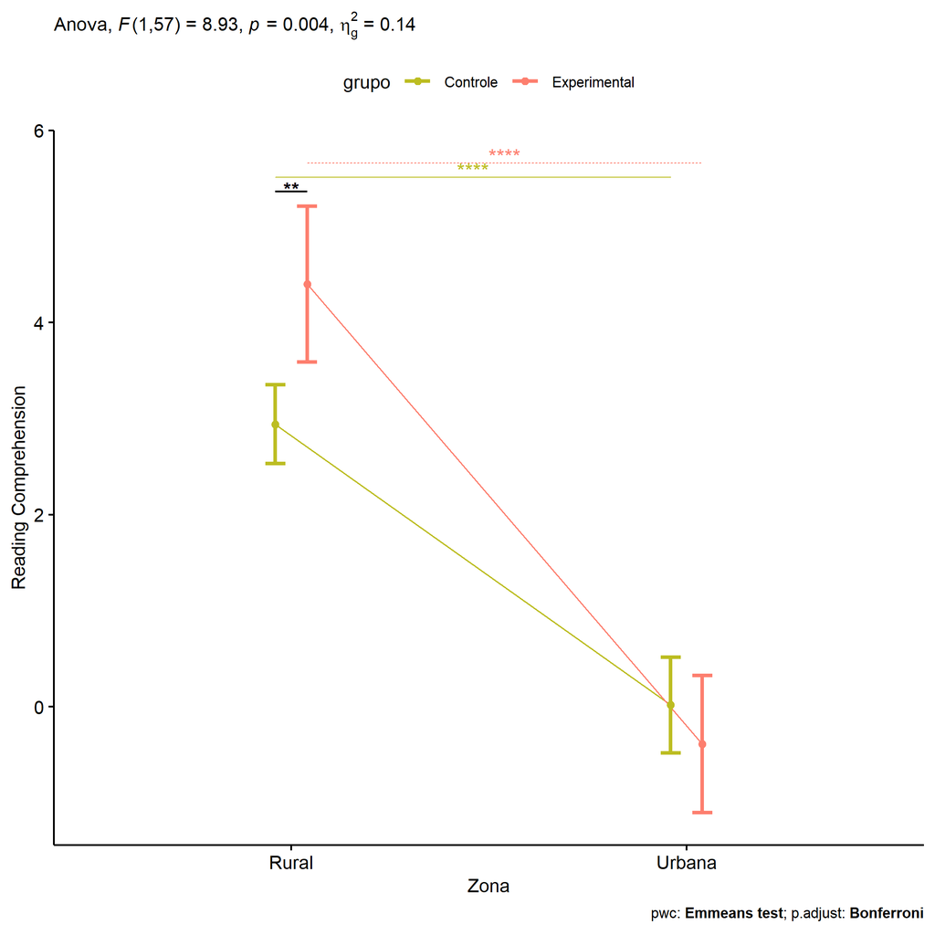

```r
if (length(unique(pdat[["Zona"]])) >= 2) {
  ggPlotAoC2(pwcs, "Zona", "grupo", aov, ylab = "Reading Comprehension",
               subtitle = which(aov$Effect == "grupo:Zona"), addParam = "errorbar") +
      ggplot2::scale_color_manual(values = color[["grupo"]]) +
      if (ymin.ci < ymax.ci) ggplot2::ylim(ymin.ci, ymax.ci)
}
```

```r
if (length(unique(pdat[["Zona"]])) >= 2) {
  plots <- twoWayAncovaBoxPlots(
    wdat, "leitura.compreensao.pos", c("grupo","Zona"), aov, pwcs, covar = "leitura.compreensao.pre",
    theme = "classic", color = color[["grupo:Zona"]],
    subtitle = which(aov$Effect == "grupo:Zona"))
}
```

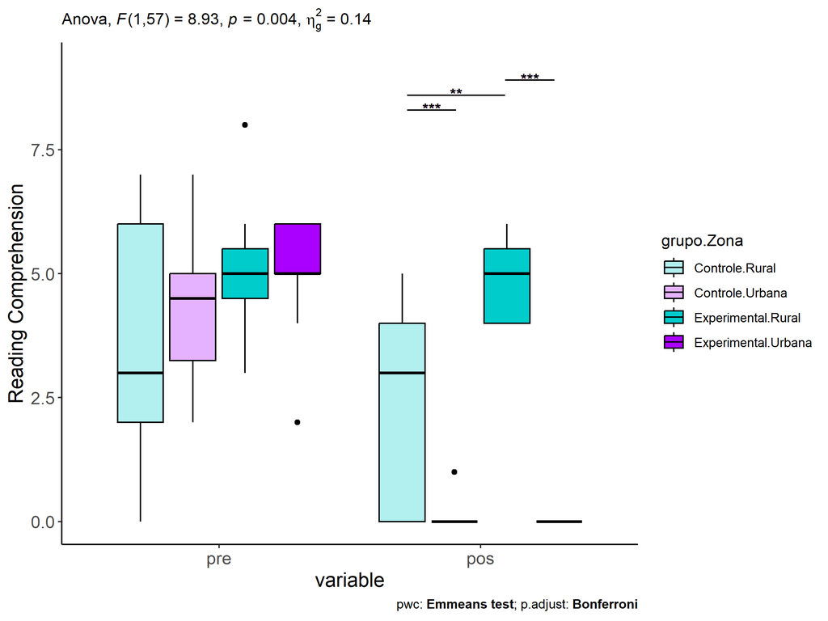

```r
if (length(unique(pdat[["Zona"]])) >= 2) {
  plots[["grupo:Zona"]] + ggplot2::ylab("Reading Comprehension") +
  ggplot2::scale_x_discrete(labels=c('pre', 'pos')) +
  if (ymin < ymax) ggplot2::ylim(ymin, ymax)
}
```

```r
if (length(unique(pdat[["Zona"]])) >= 2) {
  plots <- twoWayAncovaBoxPlots(
    wdat.long, "leitura.compreensao", c("grupo","Zona"), aov, pwc.long,
    pre.post = "time",
    theme = "classic", color = color$prepost)
}
```

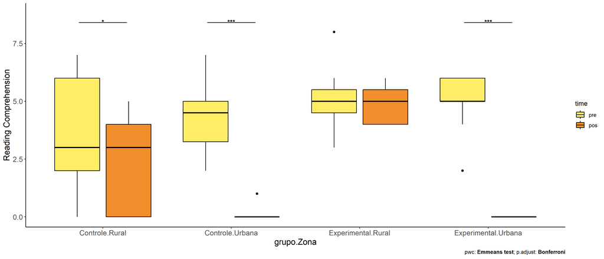

```r
if (length(unique(pdat[["Zona"]])) >= 2)
  plots[["grupo:Zona"]] + ggplot2::ylab("Reading Comprehension") +
    if (ymin < ymax) ggplot2::ylim(ymin, ymax)
```

### Checking linearity assumption

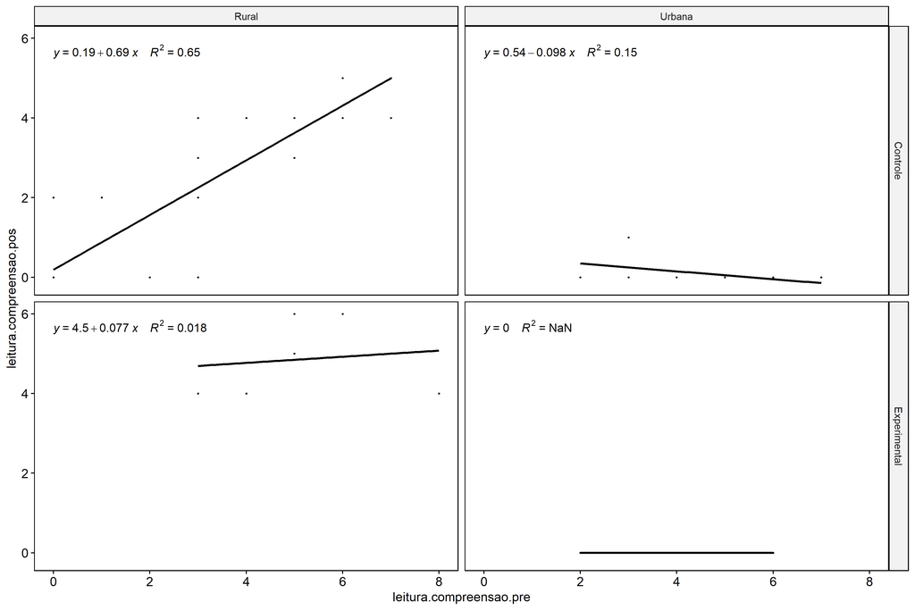

```r
if (length(unique(pdat[["Zona"]])) >= 2) {
  ggscatter(wdat, x = "leitura.compreensao.pre", y = "leitura.compreensao.pos", size = 0.5,
            facet.by = c("grupo","Zona"), add = "reg.line")+
    stat_regline_equation(
      aes(label =  paste(..eq.label.., ..rr.label.., sep = "~~~~"))
    ) +
    if (ymin < ymax) ggplot2::ylim(ymin, ymax)
}
```

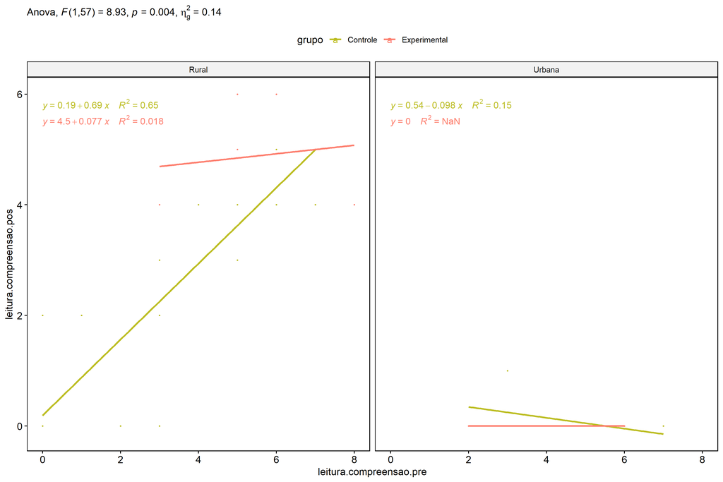

```r
if (length(unique(pdat[["Zona"]])) >= 2) {
  ggscatter(wdat, x = "leitura.compreensao.pre", y = "leitura.compreensao.pos", size = 0.5,
            color = "grupo", facet.by = "Zona", add = "reg.line")+
    stat_regline_equation(
      aes(label =  paste(..eq.label.., ..rr.label.., sep = "~~~~"), color = grupo)
    ) +
    ggplot2::labs(subtitle = rstatix::get_test_label(aov, detailed = T, row = which(aov$Effect == "grupo:Zona"))) +
    ggplot2::scale_color_manual(values = color[["grupo"]]) +
    if (ymin < ymax) ggplot2::ylim(ymin, ymax)
}
```

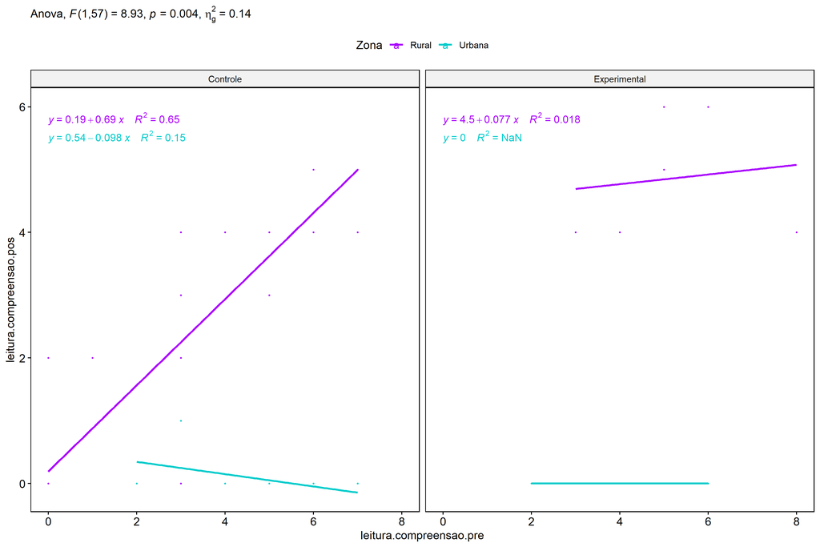

```r
if (length(unique(pdat[["Zona"]])) >= 2) {
  ggscatter(wdat, x = "leitura.compreensao.pre", y = "leitura.compreensao.pos", size = 0.5,
            color = "Zona", facet.by = "grupo", add = "reg.line")+
    stat_regline_equation(
      aes(label =  paste(..eq.label.., ..rr.label.., sep = "~~~~"), color = Zona)
    ) +
    ggplot2::labs(subtitle = rstatix::get_test_label(aov, detailed = T, row = which(aov$Effect == "grupo:Zona"))) +
    ggplot2::scale_color_manual(values = color[["Zona"]]) +
    if (ymin < ymax) ggplot2::ylim(ymin, ymax)
}
```

### Checking normality and homogeneity

```r
if (length(unique(pdat[["Zona"]])) >= 2)
  res <- augment(lm(leitura.compreensao.pos ~ leitura.compreensao.pre + grupo*Zona, data = wdat))
```

```r
if (length(unique(pdat[["Zona"]])) >= 2)
  shapiro_test(res$.resid)
```

```
## # A tibble: 1 × 3
##   variable   statistic p.value
##   <chr>          <dbl>   <dbl>
## 1 res$.resid     0.952  0.0174
```

```r
if (length(unique(pdat[["Zona"]])) >= 2)
  levene_test(res, .resid ~ grupo*Zona)
```

```
## # A tibble: 1 × 4
##     df1   df2 statistic      p
##   <int> <int>     <dbl>  <dbl>
## 1     3    58      2.70 0.0539
```

# ANCOVA and Pairwise for two factors **grupo:Cor.Raca**

## Without remove non-normal data

```r
pdat = remove_group_data(dat[!is.na(dat[["grupo"]]) & !is.na(dat[["Cor.Raca"]]),],
                         "leitura.compreensao.pos", c("grupo","Cor.Raca"))
pdat = pdat[pdat[["Cor.Raca"]] %in% do.call(
  intersect, lapply(unique(pdat[["grupo"]]), FUN = function(x) {
    unique(pdat[["Cor.Raca"]][which(pdat[["grupo"]] == x)])
  })),]
pdat[["grupo"]] = factor(pdat[["grupo"]], level[["grupo"]])
pdat[["Cor.Raca"]] = factor(
  pdat[["Cor.Raca"]],
  level[["Cor.Raca"]][level[["Cor.Raca"]] %in% unique(pdat[["Cor.Raca"]])])

pdat.long <- rbind(pdat[,c("id","grupo","Cor.Raca")], pdat[,c("id","grupo","Cor.Raca")])
pdat.long[["time"]] <- c(rep("pre", nrow(pdat)), rep("pos", nrow(pdat)))
pdat.long[["time"]] <- factor(pdat.long[["time"]], c("pre","pos"))
pdat.long[["leitura.compreensao"]] <- c(pdat[["leitura.compreensao.pre"]], pdat[["leitura.compreensao.pos"]])

if (length(unique(pdat[["Cor.Raca"]])) >= 2) {
  aov = anova_test(pdat, leitura.compreensao.pos ~ leitura.compreensao.pre + grupo*Cor.Raca)
  laov[["grupo:Cor.Raca"]] <- get_anova_table(aov)
}
```

```r
if (length(unique(pdat[["Cor.Raca"]])) >= 2) {
  pwcs <- list()
  pwcs[["Cor.Raca"]] <- emmeans_test(
    group_by(pdat, grupo), leitura.compreensao.pos ~ Cor.Raca,
    covariate = leitura.compreensao.pre, p.adjust.method = "bonferroni")
  pwcs[["grupo"]] <- emmeans_test(
    group_by(pdat, Cor.Raca), leitura.compreensao.pos ~ grupo,
    covariate = leitura.compreensao.pre, p.adjust.method = "bonferroni")

  pwc <- plyr::rbind.fill(pwcs[["grupo"]], pwcs[["Cor.Raca"]])
  pwc <- pwc[,c("grupo","Cor.Raca", colnames(pwc)[!colnames(pwc) %in% c("grupo","Cor.Raca")])]
}
```

```r
if (length(unique(pdat[["Cor.Raca"]])) >= 2) {
  pwc.long <- emmeans_test(dplyr::group_by_at(pdat.long, c("grupo","Cor.Raca")),
                           leitura.compreensao ~ time,
                           p.adjust.method = "bonferroni")
  lpwc[["grupo:Cor.Raca"]] <- plyr::rbind.fill(pwc, pwc.long)
}
```

```r
if (length(unique(pdat[["Cor.Raca"]])) >= 2) {
  ds <- get.descriptives(pdat, "leitura.compreensao.pos", c("grupo","Cor.Raca"), covar = "leitura.compreensao.pre")
  ds <- merge(ds[ds$variable != "leitura.compreensao.pre",],
              ds[ds$variable == "leitura.compreensao.pre", !colnames(ds) %in% c("variable")],
              by = c("grupo","Cor.Raca"), all.x = T, suffixes = c("", ".leitura.compreensao.pre"))
  ds <- merge(get_emmeans(pwcs[["grupo"]]), ds,
              by = c("grupo","Cor.Raca"), suffixes = c(".emms", ""))
  ds <- ds[,c("grupo","Cor.Raca","n","mean.leitura.compreensao.pre","se.leitura.compreensao.pre","mean","se",
              "emmean","se.emms","conf.low","conf.high")]

  colnames(ds) <- c("grupo","Cor.Raca", "N", paste0(c("M","SE")," (pre)"),
                    paste0(c("M","SE"), " (unadj)"),
                    paste0(c("M", "SE"), " (adj)"), "conf.low", "conf.high")

  lemms[["grupo:Cor.Raca"]] <- ds
}
```

## Computing ANCOVA and PairWise After removing non-normal data (OK)

```r
if (length(unique(pdat[["Cor.Raca"]])) >= 2) {
  wdat = pdat

  res = residuals(lm(leitura.compreensao.pos ~ leitura.compreensao.pre + grupo*Cor.Raca, data = wdat))
  non.normal = getNonNormal(res, wdat$id, plimit = 0.05)

  wdat = wdat[!wdat$id %in% non.normal,]

  wdat.long <- rbind(wdat[,c("id","grupo","Cor.Raca")], wdat[,c("id","grupo","Cor.Raca")])
  wdat.long[["time"]] <- c(rep("pre", nrow(wdat)), rep("pos", nrow(wdat)))
  wdat.long[["time"]] <- factor(wdat.long[["time"]], c("pre","pos"))
  wdat.long[["leitura.compreensao"]] <- c(wdat[["leitura.compreensao.pre"]], wdat[["leitura.compreensao.pos"]])


  ldat[["grupo:Cor.Raca"]] = wdat

  (non.normal)
}
```

```
##  [1] "P3170" "P3028" "P960"  "P613"  "P623"  "P941"  "P510"  "P614"  "P448"  "P1016" "P952"
## [12] "P3598" "P953"  "P515"  "P1089" "P459"  "P3509" "P622"  "P512"  "P445"  "P3609" "P446"
## [23] "P3518" "P936"  "P958"  "P1022" "P612"  "P3729" "P621"  "P628"  "P522"  "P1109" "P997"
## [34] "P1107" "P3524" "P3566" "P3498" "P451"  "P625"  "P1017" "P948"  "P2239" "P1097" "P3495"
## [45] "P3501" "P829"  "P3615" "P523"  "P3521" "P3508" "P945"  "P947"  "P3502" "P463"  "P1004"
## [56] "P808"  "P956"  "P3512" "P1764" "P3492" "P3239" "P1101" "P458"  "P3035" "P3040" "P3183"
## [67] "P3002" "P3008" "P3176" "P464"  "P3178" "P942"
```

```r
if (length(unique(pdat[["Cor.Raca"]])) >= 2) {
  aov = anova_test(wdat, leitura.compreensao.pos ~ leitura.compreensao.pre + grupo*Cor.Raca)
  laov[["grupo:Cor.Raca"]] <- merge(get_anova_table(aov), laov[["grupo:Cor.Raca"]],
                                         by="Effect", suffixes = c("","'"))
  df = get_anova_table(aov)
}
```

| Effect | DFn | DFd | F | p | p<.05 | ges |
| --- | --- | --- | --- | --- | --- | --- |
| leitura.compreensao.pre | 1 | 29 | 30.397 | 0.000 | * | 0.512 |
| grupo | 1 | 29 | 0.469 | 0.499 |  | 0.016 |
| Cor.Raca | 1 | 29 | 2.716 | 0.110 |  | 0.086 |
| grupo:Cor.Raca | 1 | 29 | 1.148 | 0.293 |  | 0.038 |

```r
if (length(unique(pdat[["Cor.Raca"]])) >= 2) {
  pwcs <- list()
  pwcs[["Cor.Raca"]] <- emmeans_test(
    group_by(wdat, grupo), leitura.compreensao.pos ~ Cor.Raca,
    covariate = leitura.compreensao.pre, p.adjust.method = "bonferroni")
  pwcs[["grupo"]] <- emmeans_test(
    group_by(wdat, Cor.Raca), leitura.compreensao.pos ~ grupo,
    covariate = leitura.compreensao.pre, p.adjust.method = "bonferroni")

  pwc <- plyr::rbind.fill(pwcs[["grupo"]], pwcs[["Cor.Raca"]])
  pwc <- pwc[,c("grupo","Cor.Raca", colnames(pwc)[!colnames(pwc) %in% c("grupo","Cor.Raca")])]
}
```

| grupo | Cor.Raca | term | .y. | group1 | group2 | df | statistic | p | p.adj | p.adj.signif |
| --- | --- | --- | --- | --- | --- | --- | --- | --- | --- | --- |
|  | Parda | leitura.compreensao.pre*grupo | leitura.compreensao.pos | Controle | Experimental | 29 | -1.131 | 0.267 | 0.267 | ns |
|  | Branca | leitura.compreensao.pre*grupo | leitura.compreensao.pos | Controle | Experimental | 29 | 0.566 | 0.576 | 0.576 | ns |
| Controle |  | leitura.compreensao.pre*Cor.Raca | leitura.compreensao.pos | Parda | Branca | 29 | -1.964 | 0.059 | 0.059 | ns |
| Experimental |  | leitura.compreensao.pre*Cor.Raca | leitura.compreensao.pos | Parda | Branca | 29 | 0.082 | 0.935 | 0.935 | ns |

```r
if (length(unique(pdat[["Cor.Raca"]])) >= 2) {
  pwc.long <- emmeans_test(dplyr::group_by_at(wdat.long, c("grupo","Cor.Raca")),
                           leitura.compreensao ~ time,
                           p.adjust.method = "bonferroni")
  lpwc[["grupo:Cor.Raca"]] <- merge(plyr::rbind.fill(pwc, pwc.long),
                                         lpwc[["grupo:Cor.Raca"]],
                                         by=c("grupo","Cor.Raca","term",".y.","group1","group2"),
                                         suffixes = c("","'"))
}
```

| grupo | Cor.Raca | term | .y. | group1 | group2 | df | statistic | p | p.adj | p.adj.signif |
| --- | --- | --- | --- | --- | --- | --- | --- | --- | --- | --- |
| Controle | Parda | time | leitura.compreensao | pre | pos | 60 | 2.652 | 0.010 | 0.010 | * |
| Controle | Branca | time | leitura.compreensao | pre | pos | 60 | 0.278 | 0.782 | 0.782 | ns |
| Experimental | Parda | time | leitura.compreensao | pre | pos | 60 | 0.974 | 0.334 | 0.334 | ns |
| Experimental | Branca | time | leitura.compreensao | pre | pos | 60 | 0.660 | 0.512 | 0.512 | ns |

```r
if (length(unique(pdat[["Cor.Raca"]])) >= 2) {
  ds <- get.descriptives(wdat, "leitura.compreensao.pos", c("grupo","Cor.Raca"), covar = "leitura.compreensao.pre")
  ds <- merge(ds[ds$variable != "leitura.compreensao.pre",],
              ds[ds$variable == "leitura.compreensao.pre", !colnames(ds) %in% c("variable")],
              by = c("grupo","Cor.Raca"), all.x = T, suffixes = c("", ".leitura.compreensao.pre"))
  ds <- merge(get_emmeans(pwcs[["grupo"]]), ds,
              by = c("grupo","Cor.Raca"), suffixes = c(".emms", ""))
  ds <- ds[,c("grupo","Cor.Raca","n","mean.leitura.compreensao.pre","se.leitura.compreensao.pre",
              "mean","se","emmean","se.emms","conf.low","conf.high")]

  colnames(ds) <- c("grupo","Cor.Raca", "N", paste0(c("M","SE")," (pre)"),
                    paste0(c("M","SE"), " (unadj)"),
                    paste0(c("M", "SE"), " (adj)"), "conf.low", "conf.high")

  lemms[["grupo:Cor.Raca"]] <- merge(ds, lemms[["grupo:Cor.Raca"]],
                                          by=c("grupo","Cor.Raca"), suffixes = c("","'"))
}
```

| grupo | Cor.Raca | N | M (pre) | SE (pre) | M (unadj) | SE (unadj) | M (adj) | SE (adj) | conf.low | conf.high |
| --- | --- | --- | --- | --- | --- | --- | --- | --- | --- | --- |
| Controle | Branca | 5 | 3 | 1.643 | 2.600 | 1.249 | 2.722 | 0.652 | 1.388 | 4.056 |
| Controle | Parda | 22 | 3 | 0.446 | 1.182 | 0.358 | 1.304 | 0.312 | 0.667 | 1.941 |
| Experimental | Branca | 2 | 4 | 2.000 | 2.500 | 2.500 | 2.030 | 1.034 | -0.085 | 4.145 |
| Experimental | Parda | 5 | 4 | 1.225 | 2.600 | 1.077 | 2.130 | 0.657 | 0.785 | 3.474 |

### Plots for ancova

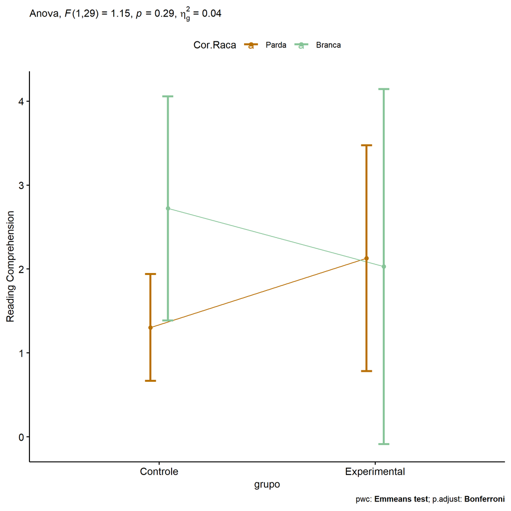

```r
if (length(unique(pdat[["Cor.Raca"]])) >= 2) {
  ggPlotAoC2(pwcs, "grupo", "Cor.Raca", aov, ylab = "Reading Comprehension",
             subtitle = which(aov$Effect == "grupo:Cor.Raca"), addParam = "errorbar") +
    ggplot2::scale_color_manual(values = color[["Cor.Raca"]]) +
    if (ymin.ci < ymax.ci) ggplot2::ylim(ymin.ci, ymax.ci)
}
```

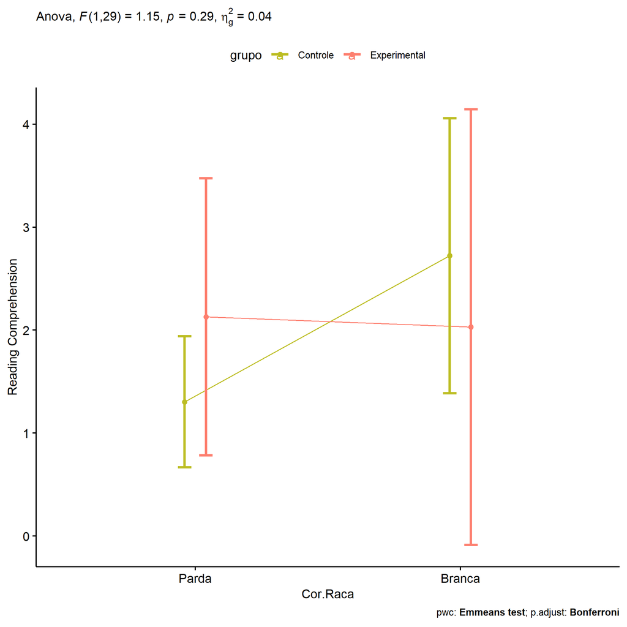

```r
if (length(unique(pdat[["Cor.Raca"]])) >= 2) {
  ggPlotAoC2(pwcs, "Cor.Raca", "grupo", aov, ylab = "Reading Comprehension",
               subtitle = which(aov$Effect == "grupo:Cor.Raca"), addParam = "errorbar") +
      ggplot2::scale_color_manual(values = color[["grupo"]]) +
      if (ymin.ci < ymax.ci) ggplot2::ylim(ymin.ci, ymax.ci)
}
```

```r
if (length(unique(pdat[["Cor.Raca"]])) >= 2) {
  plots <- twoWayAncovaBoxPlots(
    wdat, "leitura.compreensao.pos", c("grupo","Cor.Raca"), aov, pwcs, covar = "leitura.compreensao.pre",
    theme = "classic", color = color[["grupo:Cor.Raca"]],
    subtitle = which(aov$Effect == "grupo:Cor.Raca"))
}
```

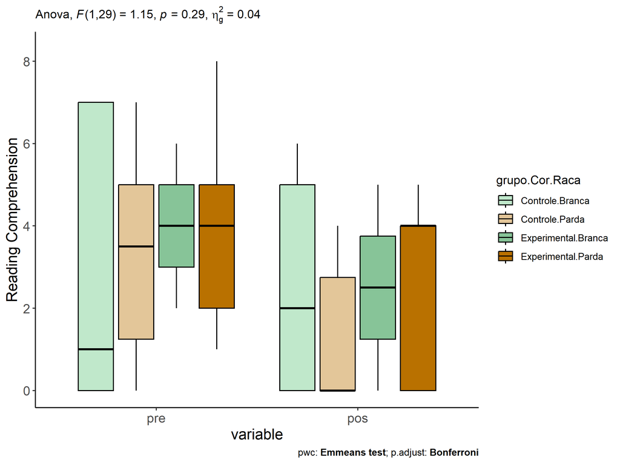

```r
if (length(unique(pdat[["Cor.Raca"]])) >= 2) {
  plots[["grupo:Cor.Raca"]] + ggplot2::ylab("Reading Comprehension") +
  ggplot2::scale_x_discrete(labels=c('pre', 'pos')) +
  if (ymin < ymax) ggplot2::ylim(ymin, ymax)
}
```

```r
if (length(unique(pdat[["Cor.Raca"]])) >= 2) {
  plots <- twoWayAncovaBoxPlots(
    wdat.long, "leitura.compreensao", c("grupo","Cor.Raca"), aov, pwc.long,
    pre.post = "time",
    theme = "classic", color = color$prepost)
}
```

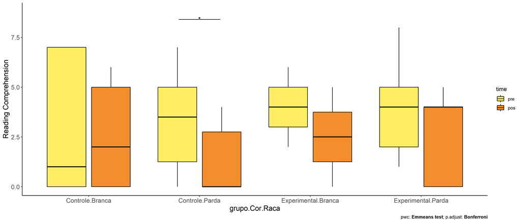

```r
if (length(unique(pdat[["Cor.Raca"]])) >= 2)
  plots[["grupo:Cor.Raca"]] + ggplot2::ylab("Reading Comprehension") +
    if (ymin < ymax) ggplot2::ylim(ymin, ymax)
```

### Checking linearity assumption

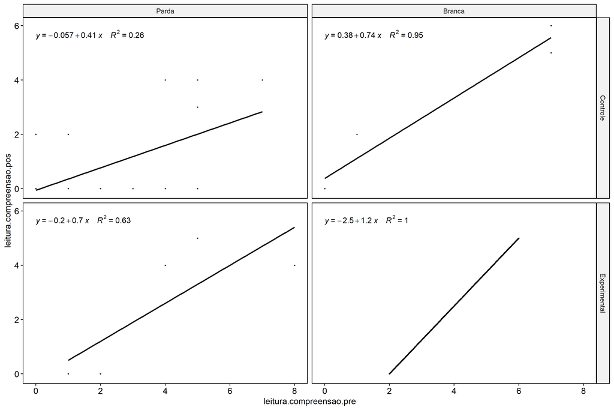

```r
if (length(unique(pdat[["Cor.Raca"]])) >= 2) {
  ggscatter(wdat, x = "leitura.compreensao.pre", y = "leitura.compreensao.pos", size = 0.5,
            facet.by = c("grupo","Cor.Raca"), add = "reg.line")+
    stat_regline_equation(
      aes(label =  paste(..eq.label.., ..rr.label.., sep = "~~~~"))
    ) +
    if (ymin < ymax) ggplot2::ylim(ymin, ymax)
}
```

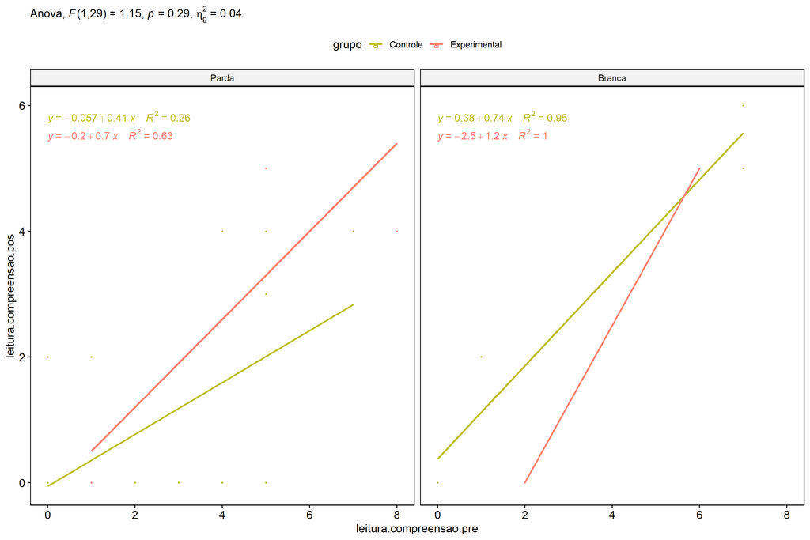

```r
if (length(unique(pdat[["Cor.Raca"]])) >= 2) {
  ggscatter(wdat, x = "leitura.compreensao.pre", y = "leitura.compreensao.pos", size = 0.5,
            color = "grupo", facet.by = "Cor.Raca", add = "reg.line")+
    stat_regline_equation(
      aes(label =  paste(..eq.label.., ..rr.label.., sep = "~~~~"), color = grupo)
    ) +
    ggplot2::labs(subtitle = rstatix::get_test_label(aov, detailed = T, row = which(aov$Effect == "grupo:Cor.Raca"))) +
    ggplot2::scale_color_manual(values = color[["grupo"]]) +
    if (ymin < ymax) ggplot2::ylim(ymin, ymax)
}
```

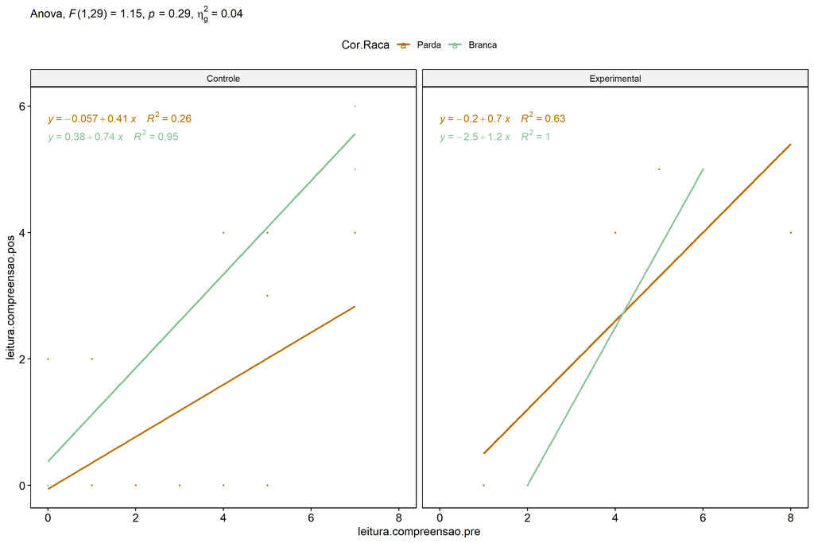

```r
if (length(unique(pdat[["Cor.Raca"]])) >= 2) {
  ggscatter(wdat, x = "leitura.compreensao.pre", y = "leitura.compreensao.pos", size = 0.5,
            color = "Cor.Raca", facet.by = "grupo", add = "reg.line")+
    stat_regline_equation(
      aes(label =  paste(..eq.label.., ..rr.label.., sep = "~~~~"), color = Cor.Raca)
    ) +
    ggplot2::labs(subtitle = rstatix::get_test_label(aov, detailed = T, row = which(aov$Effect == "grupo:Cor.Raca"))) +
    ggplot2::scale_color_manual(values = color[["Cor.Raca"]]) +
    if (ymin < ymax) ggplot2::ylim(ymin, ymax)
}
```

### Checking normality and homogeneity

```r
if (length(unique(pdat[["Cor.Raca"]])) >= 2)
  res <- augment(lm(leitura.compreensao.pos ~ leitura.compreensao.pre + grupo*Cor.Raca, data = wdat))
```

```r
if (length(unique(pdat[["Cor.Raca"]])) >= 2)
  shapiro_test(res$.resid)
```

```
## # A tibble: 1 × 3
##   variable   statistic p.value
##   <chr>          <dbl>   <dbl>
## 1 res$.resid     0.966   0.355
```

```r
if (length(unique(pdat[["Cor.Raca"]])) >= 2)
  levene_test(res, .resid ~ grupo*Cor.Raca)
```

```
## # A tibble: 1 × 4
##     df1   df2 statistic     p
##   <int> <int>     <dbl> <dbl>
## 1     3    30     0.703 0.557
```

# ANCOVA and Pairwise for two factors **grupo:Serie**

## Without remove non-normal data

```r
pdat = remove_group_data(dat[!is.na(dat[["grupo"]]) & !is.na(dat[["Serie"]]),],
                         "leitura.compreensao.pos", c("grupo","Serie"))
pdat = pdat[pdat[["Serie"]] %in% do.call(
  intersect, lapply(unique(pdat[["grupo"]]), FUN = function(x) {
    unique(pdat[["Serie"]][which(pdat[["grupo"]] == x)])
  })),]
pdat[["grupo"]] = factor(pdat[["grupo"]], level[["grupo"]])
pdat[["Serie"]] = factor(
  pdat[["Serie"]],
  level[["Serie"]][level[["Serie"]] %in% unique(pdat[["Serie"]])])

pdat.long <- rbind(pdat[,c("id","grupo","Serie")], pdat[,c("id","grupo","Serie")])
pdat.long[["time"]] <- c(rep("pre", nrow(pdat)), rep("pos", nrow(pdat)))
pdat.long[["time"]] <- factor(pdat.long[["time"]], c("pre","pos"))
pdat.long[["leitura.compreensao"]] <- c(pdat[["leitura.compreensao.pre"]], pdat[["leitura.compreensao.pos"]])

if (length(unique(pdat[["Serie"]])) >= 2) {
  aov = anova_test(pdat, leitura.compreensao.pos ~ leitura.compreensao.pre + grupo*Serie)
  laov[["grupo:Serie"]] <- get_anova_table(aov)
}
```

```r
if (length(unique(pdat[["Serie"]])) >= 2) {
  pwcs <- list()
  pwcs[["Serie"]] <- emmeans_test(
    group_by(pdat, grupo), leitura.compreensao.pos ~ Serie,
    covariate = leitura.compreensao.pre, p.adjust.method = "bonferroni")
  pwcs[["grupo"]] <- emmeans_test(
    group_by(pdat, Serie), leitura.compreensao.pos ~ grupo,
    covariate = leitura.compreensao.pre, p.adjust.method = "bonferroni")

  pwc <- plyr::rbind.fill(pwcs[["grupo"]], pwcs[["Serie"]])
  pwc <- pwc[,c("grupo","Serie", colnames(pwc)[!colnames(pwc) %in% c("grupo","Serie")])]
}
```

```r
if (length(unique(pdat[["Serie"]])) >= 2) {
  pwc.long <- emmeans_test(dplyr::group_by_at(pdat.long, c("grupo","Serie")),
                           leitura.compreensao ~ time,
                           p.adjust.method = "bonferroni")
  lpwc[["grupo:Serie"]] <- plyr::rbind.fill(pwc, pwc.long)
}
```

```r
if (length(unique(pdat[["Serie"]])) >= 2) {
  ds <- get.descriptives(pdat, "leitura.compreensao.pos", c("grupo","Serie"), covar = "leitura.compreensao.pre")
  ds <- merge(ds[ds$variable != "leitura.compreensao.pre",],
              ds[ds$variable == "leitura.compreensao.pre", !colnames(ds) %in% c("variable")],
              by = c("grupo","Serie"), all.x = T, suffixes = c("", ".leitura.compreensao.pre"))
  ds <- merge(get_emmeans(pwcs[["grupo"]]), ds,
              by = c("grupo","Serie"), suffixes = c(".emms", ""))
  ds <- ds[,c("grupo","Serie","n","mean.leitura.compreensao.pre","se.leitura.compreensao.pre","mean","se",
              "emmean","se.emms","conf.low","conf.high")]

  colnames(ds) <- c("grupo","Serie", "N", paste0(c("M","SE")," (pre)"),
                    paste0(c("M","SE"), " (unadj)"),
                    paste0(c("M", "SE"), " (adj)"), "conf.low", "conf.high")

  lemms[["grupo:Serie"]] <- ds
}
```

## Computing ANCOVA and PairWise After removing non-normal data (OK)

```r
if (length(unique(pdat[["Serie"]])) >= 2) {
  wdat = pdat

  res = residuals(lm(leitura.compreensao.pos ~ leitura.compreensao.pre + grupo*Serie, data = wdat))
  non.normal = getNonNormal(res, wdat$id, plimit = 0.05)

  wdat = wdat[!wdat$id %in% non.normal,]

  wdat.long <- rbind(wdat[,c("id","grupo","Serie")], wdat[,c("id","grupo","Serie")])
  wdat.long[["time"]] <- c(rep("pre", nrow(wdat)), rep("pos", nrow(wdat)))
  wdat.long[["time"]] <- factor(wdat.long[["time"]], c("pre","pos"))
  wdat.long[["leitura.compreensao"]] <- c(wdat[["leitura.compreensao.pre"]], wdat[["leitura.compreensao.pos"]])


  ldat[["grupo:Serie"]] = wdat

  (non.normal)
}
```

```
##  [1] "P2386" "P3049" "P123"  "P140"  "P1101" "P3035" "P3013" "P3234" "P3239" "P2226" "P3028"
## [12] "P138"  "P124"  "P1098" "P2397" "P3154" "P232"  "P3165" "P137"  "P120"  "P126"  "P3018"
## [23] "P3014" "P3092" "P3093" "P1746" "P3244" "P246"  "P3170" "P3040" "P3183" "P3555" "P1742"
## [34] "P133"  "P3002" "P3008" "P3094" "P3016" "P3516" "P1716" "P1743" "P1106" "P231"  "P3176"
## [45] "P3178" "P186"  "P3091" "P3116" "P192"  "P3167" "P228"  "P3174" "P3058" "P3027" "P182"
## [56] "P3032" "P1729" "P1701" "P130"  "P3504" "P3172"
```

```r
if (length(unique(pdat[["Serie"]])) >= 2) {
  aov = anova_test(wdat, leitura.compreensao.pos ~ leitura.compreensao.pre + grupo*Serie)
  laov[["grupo:Serie"]] <- merge(get_anova_table(aov), laov[["grupo:Serie"]],
                                         by="Effect", suffixes = c("","'"))
  df = get_anova_table(aov)
}
```

| Effect | DFn | DFd | F | p | p<.05 | ges |
| --- | --- | --- | --- | --- | --- | --- |
| leitura.compreensao.pre | 1 | 142 | 48.075 | 0.000 | * | 0.253 |
| grupo | 1 | 142 | 31.012 | 0.000 | * | 0.179 |
| Serie | 3 | 142 | 4.151 | 0.007 | * | 0.081 |
| grupo:Serie | 3 | 142 | 2.280 | 0.082 |  | 0.046 |

```r
if (length(unique(pdat[["Serie"]])) >= 2) {
  pwcs <- list()
  pwcs[["Serie"]] <- emmeans_test(
    group_by(wdat, grupo), leitura.compreensao.pos ~ Serie,
    covariate = leitura.compreensao.pre, p.adjust.method = "bonferroni")
  pwcs[["grupo"]] <- emmeans_test(
    group_by(wdat, Serie), leitura.compreensao.pos ~ grupo,
    covariate = leitura.compreensao.pre, p.adjust.method = "bonferroni")

  pwc <- plyr::rbind.fill(pwcs[["grupo"]], pwcs[["Serie"]])
  pwc <- pwc[,c("grupo","Serie", colnames(pwc)[!colnames(pwc) %in% c("grupo","Serie")])]
}
```

| grupo | Serie | term | .y. | group1 | group2 | df | statistic | p | p.adj | p.adj.signif |
| --- | --- | --- | --- | --- | --- | --- | --- | --- | --- | --- |
|  | 6 ano | leitura.compreensao.pre*grupo | leitura.compreensao.pos | Controle | Experimental | 142 | -1.606 | 0.110 | 0.110 | ns |
|  | 7 ano | leitura.compreensao.pre*grupo | leitura.compreensao.pos | Controle | Experimental | 142 | -4.495 | 0.000 | 0.000 | **** |
|  | 8 ano | leitura.compreensao.pre*grupo | leitura.compreensao.pos | Controle | Experimental | 142 | -3.522 | 0.001 | 0.001 | *** |
|  | 9 ano | leitura.compreensao.pre*grupo | leitura.compreensao.pos | Controle | Experimental | 142 | -1.658 | 0.100 | 0.100 | ns |
| Controle |  | leitura.compreensao.pre*Serie | leitura.compreensao.pos | 6 ano | 7 ano | 142 | 0.896 | 0.372 | 1.000 | ns |
| Controle |  | leitura.compreensao.pre*Serie | leitura.compreensao.pos | 6 ano | 8 ano | 142 | 2.935 | 0.004 | 0.023 | * |
| Controle |  | leitura.compreensao.pre*Serie | leitura.compreensao.pos | 6 ano | 9 ano | 142 | -0.450 | 0.654 | 1.000 | ns |
| Controle |  | leitura.compreensao.pre*Serie | leitura.compreensao.pos | 7 ano | 8 ano | 142 | 2.025 | 0.045 | 0.269 | ns |
| Controle |  | leitura.compreensao.pre*Serie | leitura.compreensao.pos | 7 ano | 9 ano | 142 | -1.297 | 0.197 | 1.000 | ns |
| Controle |  | leitura.compreensao.pre*Serie | leitura.compreensao.pos | 8 ano | 9 ano | 142 | -3.272 | 0.001 | 0.008 | ** |
| Experimental |  | leitura.compreensao.pre*Serie | leitura.compreensao.pos | 6 ano | 7 ano | 142 | -2.191 | 0.030 | 0.181 | ns |
| Experimental |  | leitura.compreensao.pre*Serie | leitura.compreensao.pos | 6 ano | 8 ano | 142 | 0.286 | 0.775 | 1.000 | ns |
| Experimental |  | leitura.compreensao.pre*Serie | leitura.compreensao.pos | 6 ano | 9 ano | 142 | -0.558 | 0.577 | 1.000 | ns |
| Experimental |  | leitura.compreensao.pre*Serie | leitura.compreensao.pos | 7 ano | 8 ano | 142 | 2.390 | 0.018 | 0.109 | ns |
| Experimental |  | leitura.compreensao.pre*Serie | leitura.compreensao.pos | 7 ano | 9 ano | 142 | 1.464 | 0.145 | 0.873 | ns |
| Experimental |  | leitura.compreensao.pre*Serie | leitura.compreensao.pos | 8 ano | 9 ano | 142 | -0.801 | 0.425 | 1.000 | ns |

```r
if (length(unique(pdat[["Serie"]])) >= 2) {
  pwc.long <- emmeans_test(dplyr::group_by_at(wdat.long, c("grupo","Serie")),
                           leitura.compreensao ~ time,
                           p.adjust.method = "bonferroni")
  lpwc[["grupo:Serie"]] <- merge(plyr::rbind.fill(pwc, pwc.long),
                                         lpwc[["grupo:Serie"]],
                                         by=c("grupo","Serie","term",".y.","group1","group2"),
                                         suffixes = c("","'"))
}
```

| grupo | Serie | term | .y. | group1 | group2 | df | statistic | p | p.adj | p.adj.signif |
| --- | --- | --- | --- | --- | --- | --- | --- | --- | --- | --- |
| Controle | 6 ano | time | leitura.compreensao | pre | pos | 286 | -1.482 | 0.139 | 0.139 | ns |
| Controle | 7 ano | time | leitura.compreensao | pre | pos | 286 | -1.565 | 0.119 | 0.119 | ns |
| Controle | 8 ano | time | leitura.compreensao | pre | pos | 286 | 0.833 | 0.406 | 0.406 | ns |
| Controle | 9 ano | time | leitura.compreensao | pre | pos | 286 | -1.429 | 0.154 | 0.154 | ns |
| Experimental | 6 ano | time | leitura.compreensao | pre | pos | 286 | -1.792 | 0.074 | 0.074 | ns |
| Experimental | 7 ano | time | leitura.compreensao | pre | pos | 286 | -3.557 | 0.000 | 0.000 | *** |
| Experimental | 8 ano | time | leitura.compreensao | pre | pos | 286 | -1.636 | 0.103 | 0.103 | ns |
| Experimental | 9 ano | time | leitura.compreensao | pre | pos | 286 | -2.633 | 0.009 | 0.009 | ** |

```r
if (length(unique(pdat[["Serie"]])) >= 2) {
  ds <- get.descriptives(wdat, "leitura.compreensao.pos", c("grupo","Serie"), covar = "leitura.compreensao.pre")
  ds <- merge(ds[ds$variable != "leitura.compreensao.pre",],
              ds[ds$variable == "leitura.compreensao.pre", !colnames(ds) %in% c("variable")],
              by = c("grupo","Serie"), all.x = T, suffixes = c("", ".leitura.compreensao.pre"))
  ds <- merge(get_emmeans(pwcs[["grupo"]]), ds,
              by = c("grupo","Serie"), suffixes = c(".emms", ""))
  ds <- ds[,c("grupo","Serie","n","mean.leitura.compreensao.pre","se.leitura.compreensao.pre",
              "mean","se","emmean","se.emms","conf.low","conf.high")]

  colnames(ds) <- c("grupo","Serie", "N", paste0(c("M","SE")," (pre)"),
                    paste0(c("M","SE"), " (unadj)"),
                    paste0(c("M", "SE"), " (adj)"), "conf.low", "conf.high")

  lemms[["grupo:Serie"]] <- merge(ds, lemms[["grupo:Serie"]],
                                          by=c("grupo","Serie"), suffixes = c("","'"))
}
```

| grupo | Serie | N | M (pre) | SE (pre) | M (unadj) | SE (unadj) | M (adj) | SE (adj) | conf.low | conf.high |
| --- | --- | --- | --- | --- | --- | --- | --- | --- | --- | --- |
| Controle | 6 ano | 29 | 4.448 | 0.367 | 5.241 | 0.288 | 5.205 | 0.316 | 4.582 | 5.829 |
| Controle | 7 ano | 26 | 3.500 | 0.527 | 4.385 | 0.524 | 4.790 | 0.338 | 4.122 | 5.459 |
| Controle | 8 ano | 21 | 4.238 | 0.516 | 3.714 | 0.570 | 3.776 | 0.371 | 3.043 | 4.509 |
| Controle | 9 ano | 26 | 4.808 | 0.408 | 5.615 | 0.289 | 5.412 | 0.334 | 4.751 | 6.073 |
| Experimental | 6 ano | 15 | 5.067 | 0.371 | 6.400 | 0.412 | 6.076 | 0.441 | 5.204 | 6.948 |
| Experimental | 7 ano | 11 | 4.545 | 0.608 | 7.636 | 0.364 | 7.555 | 0.512 | 6.542 | 8.568 |
| Experimental | 8 ano | 13 | 4.769 | 0.482 | 6.077 | 0.415 | 5.891 | 0.472 | 4.958 | 6.824 |
| Experimental | 9 ano | 10 | 3.800 | 0.512 | 6.200 | 0.629 | 6.466 | 0.539 | 5.401 | 7.531 |

### Plots for ancova

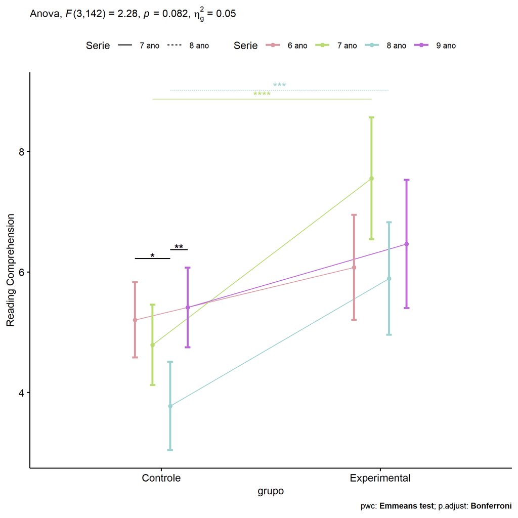

```r
if (length(unique(pdat[["Serie"]])) >= 2) {
  ggPlotAoC2(pwcs, "grupo", "Serie", aov, ylab = "Reading Comprehension",
             subtitle = which(aov$Effect == "grupo:Serie"), addParam = "errorbar") +
    ggplot2::scale_color_manual(values = color[["Serie"]]) +
    if (ymin.ci < ymax.ci) ggplot2::ylim(ymin.ci, ymax.ci)
}
```

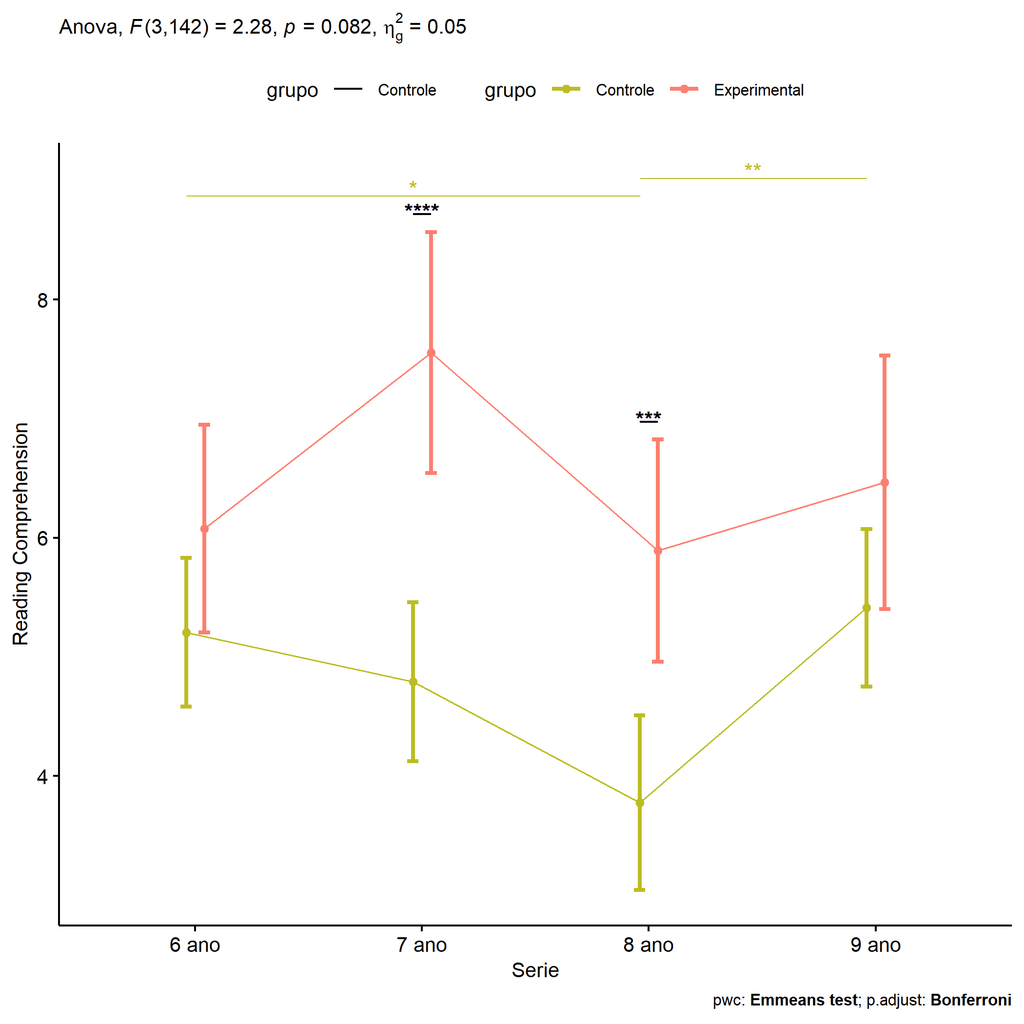

```r
if (length(unique(pdat[["Serie"]])) >= 2) {
  ggPlotAoC2(pwcs, "Serie", "grupo", aov, ylab = "Reading Comprehension",
               subtitle = which(aov$Effect == "grupo:Serie"), addParam = "errorbar") +
      ggplot2::scale_color_manual(values = color[["grupo"]]) +
      if (ymin.ci < ymax.ci) ggplot2::ylim(ymin.ci, ymax.ci)
}
```

```r
if (length(unique(pdat[["Serie"]])) >= 2) {
  plots <- twoWayAncovaBoxPlots(
    wdat, "leitura.compreensao.pos", c("grupo","Serie"), aov, pwcs, covar = "leitura.compreensao.pre",
    theme = "classic", color = color[["grupo:Serie"]],
    subtitle = which(aov$Effect == "grupo:Serie"))
}
```

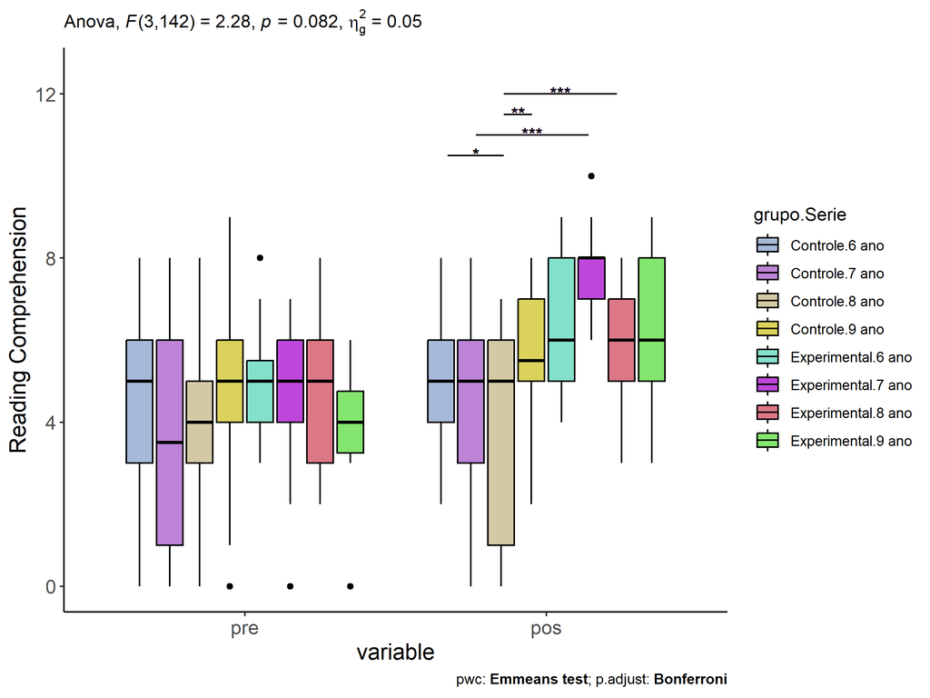

```r
if (length(unique(pdat[["Serie"]])) >= 2) {
  plots[["grupo:Serie"]] + ggplot2::ylab("Reading Comprehension") +
  ggplot2::scale_x_discrete(labels=c('pre', 'pos')) +
  if (ymin < ymax) ggplot2::ylim(ymin, ymax)
}
```

```r
if (length(unique(pdat[["Serie"]])) >= 2) {
  plots <- twoWayAncovaBoxPlots(
    wdat.long, "leitura.compreensao", c("grupo","Serie"), aov, pwc.long,
    pre.post = "time",
    theme = "classic", color = color$prepost)
}
```

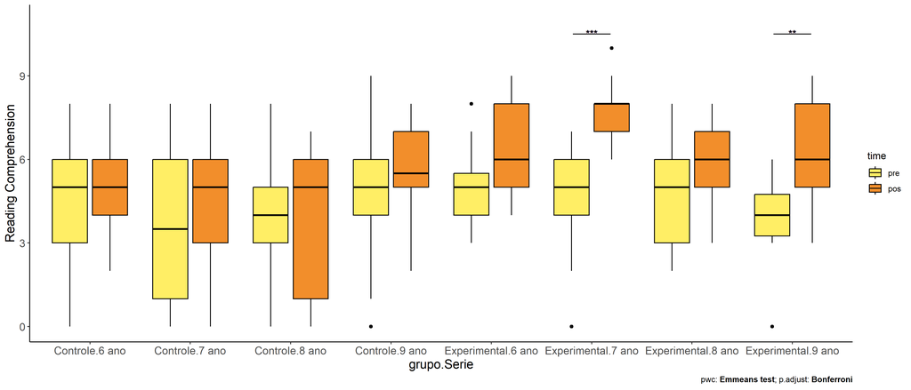

```r
if (length(unique(pdat[["Serie"]])) >= 2)
  plots[["grupo:Serie"]] + ggplot2::ylab("Reading Comprehension") +
    if (ymin < ymax) ggplot2::ylim(ymin, ymax)
```

### Checking linearity assumption

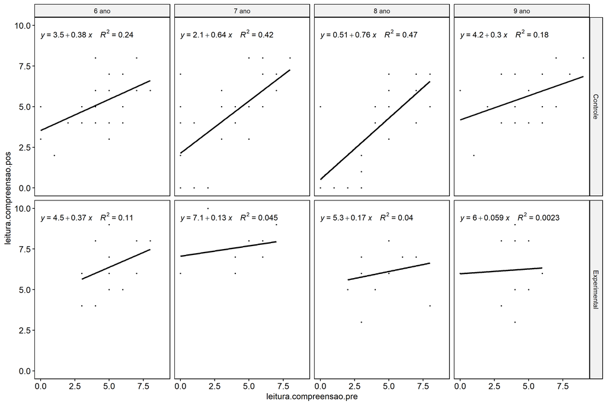

```r
if (length(unique(pdat[["Serie"]])) >= 2) {
  ggscatter(wdat, x = "leitura.compreensao.pre", y = "leitura.compreensao.pos", size = 0.5,
            facet.by = c("grupo","Serie"), add = "reg.line")+
    stat_regline_equation(
      aes(label =  paste(..eq.label.., ..rr.label.., sep = "~~~~"))
    ) +
    if (ymin < ymax) ggplot2::ylim(ymin, ymax)
}
```

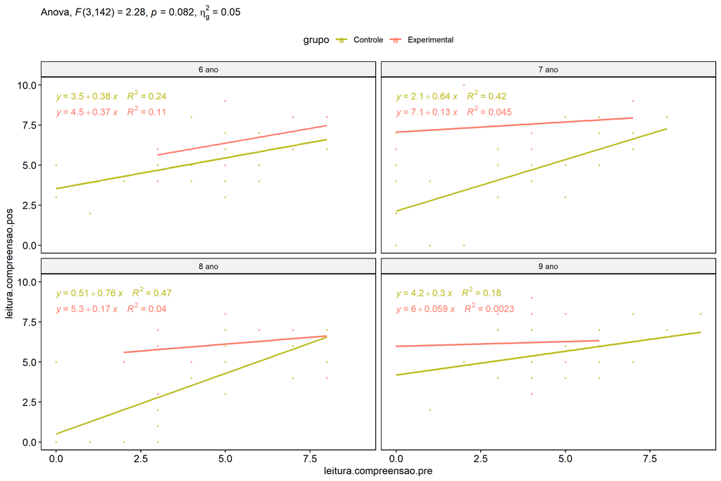

```r
if (length(unique(pdat[["Serie"]])) >= 2) {
  ggscatter(wdat, x = "leitura.compreensao.pre", y = "leitura.compreensao.pos", size = 0.5,
            color = "grupo", facet.by = "Serie", add = "reg.line")+
    stat_regline_equation(
      aes(label =  paste(..eq.label.., ..rr.label.., sep = "~~~~"), color = grupo)
    ) +
    ggplot2::labs(subtitle = rstatix::get_test_label(aov, detailed = T, row = which(aov$Effect == "grupo:Serie"))) +
    ggplot2::scale_color_manual(values = color[["grupo"]]) +
    if (ymin < ymax) ggplot2::ylim(ymin, ymax)
}
```

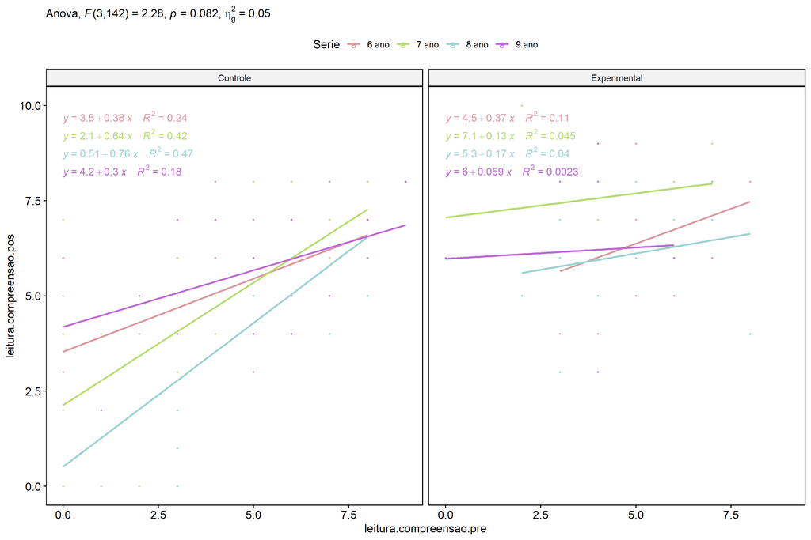

```r
if (length(unique(pdat[["Serie"]])) >= 2) {
  ggscatter(wdat, x = "leitura.compreensao.pre", y = "leitura.compreensao.pos", size = 0.5,
            color = "Serie", facet.by = "grupo", add = "reg.line")+
    stat_regline_equation(
      aes(label =  paste(..eq.label.., ..rr.label.., sep = "~~~~"), color = Serie)
    ) +
    ggplot2::labs(subtitle = rstatix::get_test_label(aov, detailed = T, row = which(aov$Effect == "grupo:Serie"))) +
    ggplot2::scale_color_manual(values = color[["Serie"]]) +
    if (ymin < ymax) ggplot2::ylim(ymin, ymax)
}
```

### Checking normality and homogeneity

```r
if (length(unique(pdat[["Serie"]])) >= 2)
  res <- augment(lm(leitura.compreensao.pos ~ leitura.compreensao.pre + grupo*Serie, data = wdat))
```

```r
if (length(unique(pdat[["Serie"]])) >= 2)
  shapiro_test(res$.resid)
```

```
## # A tibble: 1 × 3
##   variable   statistic p.value
##   <chr>          <dbl>   <dbl>
## 1 res$.resid     0.992   0.577
```

```r
if (length(unique(pdat[["Serie"]])) >= 2)
  levene_test(res, .resid ~ grupo*Serie)
```

```
## # A tibble: 1 × 4
##     df1   df2 statistic      p
##   <int> <int>     <dbl>  <dbl>
## 1     7   143      2.44 0.0216
```

# ANCOVA and Pairwise for two factors **grupo:leitura.compreensao.quintile**

## Without remove non-normal data

```r
pdat = remove_group_data(dat[!is.na(dat[["grupo"]]) & !is.na(dat[["leitura.compreensao.quintile"]]),],
                         "leitura.compreensao.pos", c("grupo","leitura.compreensao.quintile"))
pdat = pdat[pdat[["leitura.compreensao.quintile"]] %in% do.call(
  intersect, lapply(unique(pdat[["grupo"]]), FUN = function(x) {
    unique(pdat[["leitura.compreensao.quintile"]][which(pdat[["grupo"]] == x)])
  })),]
pdat[["grupo"]] = factor(pdat[["grupo"]], level[["grupo"]])
pdat[["leitura.compreensao.quintile"]] = factor(
  pdat[["leitura.compreensao.quintile"]],
  level[["leitura.compreensao.quintile"]][level[["leitura.compreensao.quintile"]] %in% unique(pdat[["leitura.compreensao.quintile"]])])

pdat.long <- rbind(pdat[,c("id","grupo","leitura.compreensao.quintile")], pdat[,c("id","grupo","leitura.compreensao.quintile")])
pdat.long[["time"]] <- c(rep("pre", nrow(pdat)), rep("pos", nrow(pdat)))
pdat.long[["time"]] <- factor(pdat.long[["time"]], c("pre","pos"))
pdat.long[["leitura.compreensao"]] <- c(pdat[["leitura.compreensao.pre"]], pdat[["leitura.compreensao.pos"]])

if (length(unique(pdat[["leitura.compreensao.quintile"]])) >= 2) {
  aov = anova_test(pdat, leitura.compreensao.pos ~ leitura.compreensao.pre + grupo*leitura.compreensao.quintile)
  laov[["grupo:leitura.compreensao.quintile"]] <- get_anova_table(aov)
}
```

```r
if (length(unique(pdat[["leitura.compreensao.quintile"]])) >= 2) {
  pwcs <- list()
  pwcs[["leitura.compreensao.quintile"]] <- emmeans_test(
    group_by(pdat, grupo), leitura.compreensao.pos ~ leitura.compreensao.quintile,
    covariate = leitura.compreensao.pre, p.adjust.method = "bonferroni")
  pwcs[["grupo"]] <- emmeans_test(
    group_by(pdat, leitura.compreensao.quintile), leitura.compreensao.pos ~ grupo,
    covariate = leitura.compreensao.pre, p.adjust.method = "bonferroni")

  pwc <- plyr::rbind.fill(pwcs[["grupo"]], pwcs[["leitura.compreensao.quintile"]])
  pwc <- pwc[,c("grupo","leitura.compreensao.quintile", colnames(pwc)[!colnames(pwc) %in% c("grupo","leitura.compreensao.quintile")])]
}
```

```r
if (length(unique(pdat[["leitura.compreensao.quintile"]])) >= 2) {
  pwc.long <- emmeans_test(dplyr::group_by_at(pdat.long, c("grupo","leitura.compreensao.quintile")),
                           leitura.compreensao ~ time,
                           p.adjust.method = "bonferroni")
  lpwc[["grupo:leitura.compreensao.quintile"]] <- plyr::rbind.fill(pwc, pwc.long)
}
```

```r
if (length(unique(pdat[["leitura.compreensao.quintile"]])) >= 2) {
  ds <- get.descriptives(pdat, "leitura.compreensao.pos", c("grupo","leitura.compreensao.quintile"), covar = "leitura.compreensao.pre")
  ds <- merge(ds[ds$variable != "leitura.compreensao.pre",],
              ds[ds$variable == "leitura.compreensao.pre", !colnames(ds) %in% c("variable")],
              by = c("grupo","leitura.compreensao.quintile"), all.x = T, suffixes = c("", ".leitura.compreensao.pre"))
  ds <- merge(get_emmeans(pwcs[["grupo"]]), ds,
              by = c("grupo","leitura.compreensao.quintile"), suffixes = c(".emms", ""))
  ds <- ds[,c("grupo","leitura.compreensao.quintile","n","mean.leitura.compreensao.pre","se.leitura.compreensao.pre","mean","se",
              "emmean","se.emms","conf.low","conf.high")]

  colnames(ds) <- c("grupo","leitura.compreensao.quintile", "N", paste0(c("M","SE")," (pre)"),
                    paste0(c("M","SE"), " (unadj)"),
                    paste0(c("M", "SE"), " (adj)"), "conf.low", "conf.high")

  lemms[["grupo:leitura.compreensao.quintile"]] <- ds
}
```

## Computing ANCOVA and PairWise After removing non-normal data (OK)

```r
if (length(unique(pdat[["leitura.compreensao.quintile"]])) >= 2) {
  wdat = pdat

  res = residuals(lm(leitura.compreensao.pos ~ leitura.compreensao.pre + grupo*leitura.compreensao.quintile, data = wdat))
  non.normal = getNonNormal(res, wdat$id, plimit = 0.05)

  wdat = wdat[!wdat$id %in% non.normal,]

  wdat.long <- rbind(wdat[,c("id","grupo","leitura.compreensao.quintile")], wdat[,c("id","grupo","leitura.compreensao.quintile")])
  wdat.long[["time"]] <- c(rep("pre", nrow(wdat)), rep("pos", nrow(wdat)))
  wdat.long[["time"]] <- factor(wdat.long[["time"]], c("pre","pos"))
  wdat.long[["leitura.compreensao"]] <- c(wdat[["leitura.compreensao.pre"]], wdat[["leitura.compreensao.pos"]])


  ldat[["grupo:leitura.compreensao.quintile"]] = wdat

  (non.normal)
}
```

```
##  [1] "P3018" "P2386" "P3014" "P246"  "P3170" "P138"  "P3040" "P124"  "P3028" "P3234" "P3239"
## [12] "P1101" "P3035" "P3154" "P232"  "P3013" "P3165" "P3183" "P2226" "P123"  "P140"  "P3049"
## [23] "P186"  "P1746" "P3091" "P3116" "P1098" "P228"  "P3174" "P2397" "P192"  "P3002" "P231"
## [34] "P3008" "P137"  "P3176" "P120"  "P126"  "P3178" "P3094" "P3016" "P3555" "P3167" "P3092"
## [45] "P2401" "P133"  "P3022" "P3055" "P3160" "P3516" "P3244" "P3606" "P3181" "P941"  "P3153"
## [56] "P247"  "P612"  "P3032" "P2383" "P3505" "P613"  "P3609" "P446"  "P3518" "P615"  "P3598"
## [67] "P626"  "P953"  "P1022" "P515"  "P521"  "P182"  "P238"  "P3031" "P1089" "P176"  "P3027"
## [78] "P1701" "P3172" "P1742" "P459"  "P3108" "P1743" "P3509" "P3615" "P3630" "P1106" "P3565"
## [89] "P174"  "P510"  "P3058" "P2385" "P1716"
```

```r
if (length(unique(pdat[["leitura.compreensao.quintile"]])) >= 2) {
  aov = anova_test(wdat, leitura.compreensao.pos ~ leitura.compreensao.pre + grupo*leitura.compreensao.quintile)
  laov[["grupo:leitura.compreensao.quintile"]] <- merge(get_anova_table(aov), laov[["grupo:leitura.compreensao.quintile"]],
                                         by="Effect", suffixes = c("","'"))
  df = get_anova_table(aov)
}
```

| Effect | DFn | DFd | F | p | p<.05 | ges |
| --- | --- | --- | --- | --- | --- | --- |
| leitura.compreensao.pre | 1 | 108 | 0.059 | 0.808 |  | 0.001 |
| grupo | 1 | 108 | 9.264 | 0.003 | * | 0.079 |
| leitura.compreensao.quintile | 4 | 108 | 1.109 | 0.356 |  | 0.039 |
| grupo:leitura.compreensao.quintile | 4 | 108 | 0.346 | 0.846 |  | 0.013 |

```r
if (length(unique(pdat[["leitura.compreensao.quintile"]])) >= 2) {
  pwcs <- list()
  pwcs[["leitura.compreensao.quintile"]] <- emmeans_test(
    group_by(wdat, grupo), leitura.compreensao.pos ~ leitura.compreensao.quintile,
    covariate = leitura.compreensao.pre, p.adjust.method = "bonferroni")
  pwcs[["grupo"]] <- emmeans_test(
    group_by(wdat, leitura.compreensao.quintile), leitura.compreensao.pos ~ grupo,
    covariate = leitura.compreensao.pre, p.adjust.method = "bonferroni")

  pwc <- plyr::rbind.fill(pwcs[["grupo"]], pwcs[["leitura.compreensao.quintile"]])
  pwc <- pwc[,c("grupo","leitura.compreensao.quintile", colnames(pwc)[!colnames(pwc) %in% c("grupo","leitura.compreensao.quintile")])]
}
```

| grupo | leitura.compreensao.quintile | term | .y. | group1 | group2 | df | statistic | p | p.adj | p.adj.signif |
| --- | --- | --- | --- | --- | --- | --- | --- | --- | --- | --- |
|  | 1st quintile | leitura.compreensao.pre*grupo | leitura.compreensao.pos | Controle | Experimental | 108 | -1.286 | 0.201 | 0.201 | ns |
|  | 2nd quintile | leitura.compreensao.pre*grupo | leitura.compreensao.pos | Controle | Experimental | 108 | -2.027 | 0.045 | 0.045 | * |
|  | 3rd quintile | leitura.compreensao.pre*grupo | leitura.compreensao.pos | Controle | Experimental | 108 | -1.378 | 0.171 | 0.171 | ns |
|  | 4th quintile | leitura.compreensao.pre*grupo | leitura.compreensao.pos | Controle | Experimental | 108 | -0.562 | 0.575 | 0.575 | ns |
|  | 5th quintile | leitura.compreensao.pre*grupo | leitura.compreensao.pos | Controle | Experimental | 108 | -1.630 | 0.106 | 0.106 | ns |
| Controle |  | leitura.compreensao.pre*leitura.compreensao.quintile | leitura.compreensao.pos | 1st quintile | 2nd quintile | 108 | -0.763 | 0.447 | 1.000 | ns |
| Controle |  | leitura.compreensao.pre*leitura.compreensao.quintile | leitura.compreensao.pos | 1st quintile | 3rd quintile | 108 | -1.629 | 0.106 | 1.000 | ns |
| Controle |  | leitura.compreensao.pre*leitura.compreensao.quintile | leitura.compreensao.pos | 1st quintile | 4th quintile | 108 | -1.736 | 0.085 | 0.854 | ns |
| Controle |  | leitura.compreensao.pre*leitura.compreensao.quintile | leitura.compreensao.pos | 1st quintile | 5th quintile | 108 | -1.731 | 0.086 | 0.864 | ns |
| Controle |  | leitura.compreensao.pre*leitura.compreensao.quintile | leitura.compreensao.pos | 2nd quintile | 3rd quintile | 108 | -1.965 | 0.052 | 0.520 | ns |
| Controle |  | leitura.compreensao.pre*leitura.compreensao.quintile | leitura.compreensao.pos | 2nd quintile | 4th quintile | 108 | -2.112 | 0.037 | 0.370 | ns |
| Controle |  | leitura.compreensao.pre*leitura.compreensao.quintile | leitura.compreensao.pos | 2nd quintile | 5th quintile | 108 | -2.064 | 0.041 | 0.414 | ns |
| Controle |  | leitura.compreensao.pre*leitura.compreensao.quintile | leitura.compreensao.pos | 3rd quintile | 4th quintile | 108 | -1.365 | 0.175 | 1.000 | ns |
| Controle |  | leitura.compreensao.pre*leitura.compreensao.quintile | leitura.compreensao.pos | 3rd quintile | 5th quintile | 108 | -1.608 | 0.111 | 1.000 | ns |
| Controle |  | leitura.compreensao.pre*leitura.compreensao.quintile | leitura.compreensao.pos | 4th quintile | 5th quintile | 108 | -0.913 | 0.364 | 1.000 | ns |
| Experimental |  | leitura.compreensao.pre*leitura.compreensao.quintile | leitura.compreensao.pos | 1st quintile | 2nd quintile | 108 | -1.093 | 0.277 | 1.000 | ns |
| Experimental |  | leitura.compreensao.pre*leitura.compreensao.quintile | leitura.compreensao.pos | 1st quintile | 3rd quintile | 108 | -1.235 | 0.219 | 1.000 | ns |
| Experimental |  | leitura.compreensao.pre*leitura.compreensao.quintile | leitura.compreensao.pos | 1st quintile | 4th quintile | 108 | -1.300 | 0.196 | 1.000 | ns |
| Experimental |  | leitura.compreensao.pre*leitura.compreensao.quintile | leitura.compreensao.pos | 1st quintile | 5th quintile | 108 | -1.814 | 0.073 | 0.725 | ns |
| Experimental |  | leitura.compreensao.pre*leitura.compreensao.quintile | leitura.compreensao.pos | 2nd quintile | 3rd quintile | 108 | -0.436 | 0.664 | 1.000 | ns |
| Experimental |  | leitura.compreensao.pre*leitura.compreensao.quintile | leitura.compreensao.pos | 2nd quintile | 4th quintile | 108 | -0.806 | 0.422 | 1.000 | ns |
| Experimental |  | leitura.compreensao.pre*leitura.compreensao.quintile | leitura.compreensao.pos | 2nd quintile | 5th quintile | 108 | -1.594 | 0.114 | 1.000 | ns |
| Experimental |  | leitura.compreensao.pre*leitura.compreensao.quintile | leitura.compreensao.pos | 3rd quintile | 4th quintile | 108 | -0.697 | 0.487 | 1.000 | ns |
| Experimental |  | leitura.compreensao.pre*leitura.compreensao.quintile | leitura.compreensao.pos | 3rd quintile | 5th quintile | 108 | -1.890 | 0.061 | 0.614 | ns |
| Experimental |  | leitura.compreensao.pre*leitura.compreensao.quintile | leitura.compreensao.pos | 4th quintile | 5th quintile | 108 | -1.154 | 0.251 | 1.000 | ns |

```r
if (length(unique(pdat[["leitura.compreensao.quintile"]])) >= 2) {
  pwc.long <- emmeans_test(dplyr::group_by_at(wdat.long, c("grupo","leitura.compreensao.quintile")),
                           leitura.compreensao ~ time,
                           p.adjust.method = "bonferroni")
  lpwc[["grupo:leitura.compreensao.quintile"]] <- merge(plyr::rbind.fill(pwc, pwc.long),
                                         lpwc[["grupo:leitura.compreensao.quintile"]],
                                         by=c("grupo","leitura.compreensao.quintile","term",".y.","group1","group2"),
                                         suffixes = c("","'"))
}
```

| grupo | leitura.compreensao.quintile | term | .y. | group1 | group2 | df | statistic | p | p.adj | p.adj.signif |
| --- | --- | --- | --- | --- | --- | --- | --- | --- | --- | --- |
| Controle | 1st quintile | time | leitura.compreensao | pre | pos | 218 | -7.110 | 0.000 | 0.000 | **** |
| Controle | 2nd quintile | time | leitura.compreensao | pre | pos | 218 | -1.505 | 0.134 | 0.134 | ns |
| Controle | 3rd quintile | time | leitura.compreensao | pre | pos | 218 | -1.568 | 0.118 | 0.118 | ns |
| Controle | 4th quintile | time | leitura.compreensao | pre | pos | 218 | 0.500 | 0.617 | 0.617 | ns |
| Controle | 5th quintile | time | leitura.compreensao | pre | pos | 218 | 2.495 | 0.013 | 0.013 | * |
| Experimental | 1st quintile | time | leitura.compreensao | pre | pos | 218 | -4.054 | 0.000 | 0.000 | **** |
| Experimental | 2nd quintile | time | leitura.compreensao | pre | pos | 218 | -3.347 | 0.001 | 0.001 | *** |
| Experimental | 3rd quintile | time | leitura.compreensao | pre | pos | 218 | -2.422 | 0.016 | 0.016 | * |
| Experimental | 4th quintile | time | leitura.compreensao | pre | pos | 218 | -0.360 | 0.719 | 0.719 | ns |
| Experimental | 5th quintile | time | leitura.compreensao | pre | pos | 218 | -0.558 | 0.577 | 0.577 | ns |

```r
if (length(unique(pdat[["leitura.compreensao.quintile"]])) >= 2) {
  ds <- get.descriptives(wdat, "leitura.compreensao.pos", c("grupo","leitura.compreensao.quintile"), covar = "leitura.compreensao.pre")
  ds <- merge(ds[ds$variable != "leitura.compreensao.pre",],
              ds[ds$variable == "leitura.compreensao.pre", !colnames(ds) %in% c("variable")],
              by = c("grupo","leitura.compreensao.quintile"), all.x = T, suffixes = c("", ".leitura.compreensao.pre"))
  ds <- merge(get_emmeans(pwcs[["grupo"]]), ds,
              by = c("grupo","leitura.compreensao.quintile"), suffixes = c(".emms", ""))
  ds <- ds[,c("grupo","leitura.compreensao.quintile","n","mean.leitura.compreensao.pre","se.leitura.compreensao.pre",
              "mean","se","emmean","se.emms","conf.low","conf.high")]

  colnames(ds) <- c("grupo","leitura.compreensao.quintile", "N", paste0(c("M","SE")," (pre)"),
                    paste0(c("M","SE"), " (unadj)"),
                    paste0(c("M", "SE"), " (adj)"), "conf.low", "conf.high")

  lemms[["grupo:leitura.compreensao.quintile"]] <- merge(ds, lemms[["grupo:leitura.compreensao.quintile"]],
                                          by=c("grupo","leitura.compreensao.quintile"), suffixes = c("","'"))
}
```

| grupo | leitura.compreensao.quintile | N | M (pre) | SE (pre) | M (unadj) | SE (unadj) | M (adj) | SE (adj) | conf.low | conf.high |
| --- | --- | --- | --- | --- | --- | --- | --- | --- | --- | --- |
| Controle | 1st quintile | 17 | 0.412 | 0.173 | 3.176 | 0.551 | 2.897 | 1.209 | 0.500 | 5.294 |
| Controle | 2nd quintile | 11 | 3.000 | 0.000 | 3.727 | 0.524 | 3.632 | 0.604 | 2.435 | 4.830 |
| Controle | 3rd quintile | 31 | 4.548 | 0.091 | 5.000 | 0.227 | 5.016 | 0.282 | 4.456 | 5.575 |
| Controle | 4th quintile | 14 | 6.000 | 0.000 | 5.786 | 0.318 | 5.905 | 0.639 | 4.638 | 7.173 |
| Controle | 5th quintile | 16 | 7.312 | 0.120 | 6.312 | 0.299 | 6.526 | 0.957 | 4.629 | 8.423 |
| Experimental | 1st quintile | 4 | 1.000 | 0.577 | 4.250 | 1.436 | 4.012 | 1.242 | 1.551 | 6.474 |
| Experimental | 2nd quintile | 5 | 3.000 | 0.000 | 5.400 | 0.600 | 5.305 | 0.788 | 3.744 | 6.867 |
| Experimental | 3rd quintile | 13 | 4.615 | 0.140 | 5.692 | 0.263 | 5.713 | 0.433 | 4.855 | 6.571 |
| Experimental | 4th quintile | 3 | 6.000 | 0.000 | 6.333 | 0.882 | 6.453 | 1.011 | 4.449 | 8.457 |
| Experimental | 5th quintile | 5 | 7.200 | 0.200 | 7.600 | 0.510 | 7.805 | 1.087 | 5.651 | 9.959 |